# Dynamiques globales : Analyse du développement socioéconomique des pays de 1880 à 2010

**Introduction**

La présente étude se consacre à l’examen approfondi des dynamiques du statut socioéconomique (SES) à l’échelle mondiale sur une période de 130 ans, s’étendant de 1880 à 2010. Le SES, considéré comme un indicateur composite, englobe divers aspects, dont le revenu par habitant et les niveaux d’éducation. L’exploration des variations de ces scores à travers le temps met en lumière des informations clés sur les tendances de développement mondial ainsi que sur les changements dans les structures économiques et éducatives entre les nations.

**À propos des données**

La base de données intitulée “Country Socioeconomic Status Scores: 1880-2010”, élaborée par Shawn Dorius, propose des estimations sur la position socioéconomique de 149 pays sur une durée significative de 130 ans. Les scores de SES, variant de 1 à 99, agrègent les classements fondés sur les revenus et l’éducation par pays, permettant une analyse comparative de l’évolution socioéconomique mondiale. Cette base de données s’appuie sur une multitude de sources, incluant les indicateurs économiques de Maddison et les données éducatives de Barro-Lee, facilitant ainsi une évaluation diachronique et exhaustive du statut socioéconomique global.

```
Descriptions des variables :

    UNID : Code pays numérique ISO utilisé par les Nations Unies.
    WBID : Code pays alpha ISO utilisé par la Banque Mondiale.
    SES : Score de statut socioéconomique (1-99) pour chaque pays, calculé à partir d'indicateurs économiques et éducatifs.
    country : Nom abrégé du pays.
    year : Année de l'enquête.
    gdppc : PIB par habitant (série temporelle unique imputée).
    yrseduc : Années d'éducation complétées dans la population adulte (âgée de 15 ans et plus).
    popshare : Part de la population totale.
```

**Objectifs**

L’objectif de cette recherche est de démêler les tendances globales en matière de SES et d’analyser les contributions relatives du niveau d’éducation et du produit intérieur brut (PIB) par habitant à ces tendances, tout en scrutant les disparités régionales et temporelles influençant le développement mondial. Cette démarche est cruciale pour informer les stratégies de développement et les politiques économiques à l’échelle internationale face aux dynamiques socioéconomiques en mutation.

**Questions de recherche**

Cette recherche est guidée par des questions fondamentales :

```
Quelles tendances prédominantes émergent-elles dans l'évolution du SES entre 1880 et 2010 ?
Quelle est la corrélation entre l'éducation, le PIB par habitant, et le SES ?
En quoi les disparités régionales affectent-elles le panorama socioéconomique global ?
Quelles implications ces tendances ont-elles pour les stratégies de développement et les politiques économiques ?
```

**Hypothèses de recherche**

Plusieurs hypothèses sous-tendent cette étude :

```
Hypothèse de complexité éducative : La relation entre le niveau d'éducation et le SES est perçue comme multidimensionnelle, influencée positivement par l'augmentation des années d'éducation moyennes, tout en étant modulée par des facteurs contextuels variés.

Hypothèse de dynamique économique : Le PIB par habitant est envisagé comme un prédicteur du SES, tout en reconnaissant ses limites à refléter le bien-être social complet et les inégalités internes aux nations.

Hypothèse de disparité régionale : Des écarts régionaux significatifs sont présumés dans le développement socioéconomique, interprétés à travers un prisme incluant divers facteurs historiques, culturels, politiques et environnementaux.

Hypothèse d'évolution historique : L'évolution du SES depuis 1880 est interprétée comme le résultat d'une multitude de forces, incluant la mondialisation et les innovations, mais aussi comme étant affectée par des cycles économiques et des crises globales.

Hypothèse de politiques différenciées : Les fluctuations du SES sont censées influencer et être influencées par les stratégies de développement et les décisions politiques, soulignant une interaction réciproque nécessitant des approches spécifiques et contextualisées.
```

**Méthodologie**

La méthodologie adoptée pour cette recherche s’articule autour de diverses approches analytiques, essentielles pour déchiffrer et comprendre les dynamiques socioéconomiques. Elle initie par une analyse descriptive, soulignant les tendances, dispersions, et anomalies présentes dans les données. Une exploration temporelle succède, mettant en lumière les modèles de développement et les évolutions historiques significatives. À cela s’ajoutent des analyses corrélationnelles et de clustering, qui facilitent l’examen des relations entre variables et le regroupement des pays en fonction de caractéristiques similaires. La visualisation des données occupe une place centrale, rendant l’interprétation et la communication des résultats plus accessibles et intuitives.

L’introduction de l’analyse de variance (ANOVA) pour évaluer les différences de SES entre les pays, suivie par les tests post-hoc de Tukey, permet une discrimination plus fine des variations inter-nationales. La régression multivariée approfondit l’investigation des liens entre l’éducation, le SES, et le PIB par habitant, ajoutant une couche supplémentaire de nuance à notre compréhension. Parallèlement, l’étude spécifique sur la Chine, illustrant l’évolution de ses indicateurs socioéconomiques, enrichit l’analyse globale par un cas concret, reflétant les transformations et les tendances au sein d’un contexte national particulier.

```r
# Définir le miroir CRAN
options(repos = "https://cran.r-project.org")
```

```r
suppress_output <- function(expr) {
  sink(tempfile())
  on.exit(sink())
  invisible(expr)
}

suppress_output({
  install.packages("here", quietly = TRUE)
  install.packages("mice", quietly = TRUE)
  install.packages("ggplot2", quietly = TRUE)
  install.packages("zoo", quietly = TRUE)
  install.packages("naniar", quietly = TRUE)
  install.packages("tidyverse", quietly = TRUE)
  install.packages("readr", quietly = TRUE)
  install.packages("tibble", quietly = TRUE)
  install.packages("stringr", quietly = TRUE)
  install.packages("magrittr", quietly = TRUE)
  install.packages("dplyr", quietly = TRUE)
  install.packages("corrplot", quietly = TRUE)
  install.packages("car", quietly = TRUE)
  install.packages("caret", quietly = TRUE)
  install.packages("nortest", quietly = TRUE)
  install.packages("VIM", quietly = TRUE)
  install.packages("rpart", quietly = TRUE)
  install.packages("rpart.plot", quietly = TRUE)
  install.packages("psych", quietly = TRUE)
  install.packages("gt", quietly = TRUE)
  install.packages("reshape2", quietly = TRUE)
  install.packages("lmtest", quietly = TRUE)
  install.packages("sandwich", quietly = TRUE)
})
```

```
## installing the source package 'naniar'
```

```r
suppressWarnings({
  suppressPackageStartupMessages({
    library(here)
    library(mice)
    library(ggplot2)
    library(zoo)
    library(naniar)
    library(tidyverse)
    library(readr)
    library(tibble)
    library(stringr)
    library(magrittr)
    library(dplyr)
    library(corrplot)
    library(caret)
    library(nortest)
    library(VIM)
    library(rpart)
    library(rpart.plot)
    library(psych)
    library(gt)
    library(reshape2)
    library(lmtest)
    library(sandwich)
    library(car)
  })
})
```

| **1. Chargement des données et visualisation préliminaire** |
| --- |

```r
# Définir le chemin du fichier
file_path <- "R Projects - Country Socioeconomic Status Scores/glob.ses.csv"
data <- read.csv(file_path)

# Trier les données globalement par pays puis par année
sorted_data <- data %>%
  dplyr::arrange(country, year)

# Visualisation préliminaire des données triées
head(sorted_data)
```

```
##   unid wbid     country year      SES    gdppc yrseduc    popshare
## 1    4  AFG Afghanistan 1880 37.95745 585.4651      NA 0.003271174
## 2    4  AFG Afghanistan 1890 29.59139 635.9302      NA 0.003255497
## 3    4  AFG Afghanistan 1900 28.10480 686.3953      NA 0.003244502
## 4    4  AFG Afghanistan 1910 26.98760 736.8605      NA 0.003178434
## 5    4  AFG Afghanistan 1920 26.96802 731.7568      NA 0.003244601
## 6    4  AFG Afghanistan 1930 15.30677 702.8378      NA 0.003258729
```

```r
str(sorted_data)
```

```
## 'data.frame':    2086 obs. of  8 variables:
##  $ unid    : int  4 4 4 4 4 4 4 4 4 4 ...
##  $ wbid    : chr  "AFG" "AFG" "AFG" "AFG" ...
##  $ country : chr  "Afghanistan" "Afghanistan" "Afghanistan" "Afghanistan" ...
##  $ year    : int  1880 1890 1900 1910 1920 1930 1940 1950 1960 1970 ...
##  $ SES     : num  38 29.6 28.1 27 27 ...
##  $ gdppc   : num  585 636 686 737 732 ...
##  $ yrseduc : num  NA NA NA NA NA NA NA NA NA NA ...
##  $ popshare: num  0.00327 0.00326 0.00324 0.00318 0.00324 ...
```

| **2. Évaluation des données** |
| --- |

```r
# Vérification des valeurs manquantes
valeurs_manquantes <- colSums(is.na(data))
print(valeurs_manquantes)
```

```
##     unid     wbid  country     year      SES    gdppc  yrseduc popshare
##        0        0        0        0        0        0     1050        0
```

```r
# Recherche de duplicatas dans les données
lignes_dupliquees <- sum(duplicated(data))
print(lignes_dupliquees)
```

```
## [1] 0
```

```r
# Résumé statistique des données pour une meilleure compréhension
summary(data)
```

```
##       unid           wbid             country               year
##  Min.   :  4.0   Length:2086        Length:2086        Min.   :1880
##  1st Qu.:214.0   Class :character   Class :character   1st Qu.:1910
##  Median :426.0   Mode  :character   Mode  :character   Median :1945
##  Mean   :430.8                                         Mean   :1945
##  3rd Qu.:642.0                                         3rd Qu.:1980
##  Max.   :894.0                                         Max.   :2010
##
##       SES              gdppc             yrseduc           popshare
##  Min.   : 0.2728   Min.   :   324.0   Min.   : 0.0400   Min.   :8.950e-06
##  1st Qu.:36.7169   1st Qu.:   811.8   1st Qu.: 0.9463   1st Qu.:4.788e-04
##  Median :61.8308   Median :  1563.6   Median : 2.8132   Median :1.437e-03
##  Mean   :56.6898   Mean   :  5202.9   Mean   : 3.7782   Mean   :6.711e-03
##  3rd Qu.:77.0577   3rd Qu.:  4284.2   3rd Qu.: 6.2486   3rd Qu.:3.669e-03
##  Max.   :99.7337   Max.   :126144.7   Max.   :13.0971   Max.   :2.639e-01
##                                       NA's   :1050
```

| **3. Nettoyage des données** |
| --- |

```r
# Correction des noms de pays pour éviter les problèmes d'encodage
data <- data %>%
  mutate(country = str_replace_all(country, "�", "e"))

# Assurer que 'year' soit traité comme une valeur numérique pour prévenir des erreurs dans les analyses futures
data <- data %>%
  mutate(year = as.numeric(year))

# Conversion des autres variables numériques
data <- data %>%
  mutate(SES = as.numeric(SES),
         gdppc = as.numeric(gdppc),
         yrseduc = as.numeric(yrseduc),
         popshare = as.numeric(popshare))

# Trier les données globalement par pays puis par année
sorted_data <- data %>%
  arrange(country, year)

# Visualiser les 30 premières lignes
head(sorted_data, 30)
```

```
##    unid wbid     country year       SES     gdppc yrseduc    popshare
## 1     4  AFG Afghanistan 1880 37.957447  585.4651      NA 0.003271174
## 2     4  AFG Afghanistan 1890 29.591391  635.9302      NA 0.003255497
## 3     4  AFG Afghanistan 1900 28.104797  686.3953      NA 0.003244502
## 4     4  AFG Afghanistan 1910 26.987600  736.8605      NA 0.003178434
## 5     4  AFG Afghanistan 1920 26.968016  731.7568      NA 0.003244601
## 6     4  AFG Afghanistan 1930 15.306766  702.8378      NA 0.003258729
## 7     4  AFG Afghanistan 1940 14.320977  673.9189      NA 0.003226468
## 8     4  AFG Afghanistan 1950 23.424145  645.0000      NA 0.003302099
## 9     4  AFG Afghanistan 1960 15.763076  739.0000      NA 0.003039381
## 10    4  AFG Afghanistan 1970  3.474212  709.0000      NA 0.003097430
## 11    4  AFG Afghanistan 1980  3.465048  690.0000      NA 0.003057307
## 12    4  AFG Afghanistan 1990  1.269530  604.0000      NA 0.002346751
## 13    4  AFG Afghanistan 2000  2.061114  565.0000      NA 0.003308824
## 14    4  AFG Afghanistan 2010  5.676400 1662.8035      NA 0.004149612
```

[output cut: 16 more lines]

```r
# Visualiser les 30 dernières lignes
tail(sorted_data, 30)
```

```
##      unid wbid  country year      SES     gdppc yrseduc    popshare
## 2057  887  YEM    Yemen 2000 29.74600 3911.2197      NA 0.002988601
## 2058  887  YEM    Yemen 2010 19.49229 4481.5547      NA 0.003501065
## 2059  894  ZMB   Zambia 1880 31.15159  533.6667  0.6200 0.000861690
## 2060  894  ZMB   Zambia 1890 41.41512  567.3333  0.6200 0.000878592
## 2061  894  ZMB   Zambia 1900 51.36847  601.0000  0.6200 0.000891454
## 2062  894  ZMB   Zambia 1910 39.16855  628.6923  0.6200 0.000885438
## 2063  894  ZMB   Zambia 1920 38.32968  682.6296  0.6300 0.000944724
## 2064  894  ZMB   Zambia 1930 36.72639  747.8148  0.6700 0.000984045
## 2065  894  ZMB   Zambia 1940 52.42276  813.0000  1.6600 0.000996298
## 2066  894  ZMB   Zambia 1950 52.15458  661.0000  2.3600 0.001034341
## 2067  894  ZMB   Zambia 1960 42.52134  960.0000  2.2564 0.001030469
## 2068  894  ZMB   Zambia 1970 43.07513 1073.0000  2.9747 0.001165705
## 2069  894  ZMB   Zambia 1980 24.03583  911.0000  3.6116 0.001372169
## 2070  894  ZMB   Zambia 1990 45.69716 2308.6038  4.8925 0.001583577
```

[output cut: 16 more lines]

| **4. Visualisation des tendances** |
| --- |

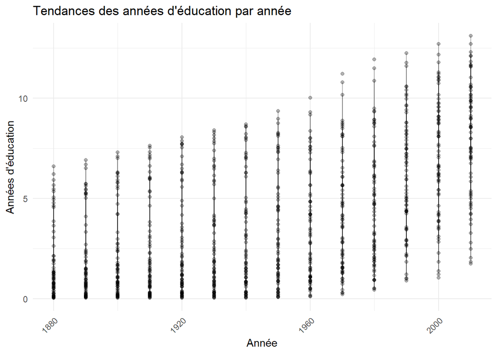

[output not shown]

```r
# Création d'un graphique pour visualiser les tendances des années d'éducation
ggplot(data, aes(x = year, y = yrseduc)) +
  geom_line(alpha = 0.3) +
  geom_point(alpha = 0.3) +
  theme_minimal() +
  labs(title = "Tendances des années d'éducation par année", x = "Année", y = "Années d'éducation") +
  theme(axis.text.x = element_text(angle = 45, hjust = 1))
```

```r
# Évaluation des corrélations entre 'yrseduc', 'SES', et 'gdppc'
data_non_na <- na.omit(data[, c("yrseduc", "SES", "gdppc")])
cor_matrix <- cor(data_non_na)
print(cor_matrix)
```

```
##           yrseduc       SES     gdppc
## yrseduc 1.0000000 0.7053500 0.7298154
## SES     0.7053500 1.0000000 0.4664593
## gdppc   0.7298154 0.4664593 1.0000000
```

# Préparation des données : Imputation et analyse preliminaire

La première étape du processus de préparation des données a impliqué une évaluation méticuleuse pour identifier et corriger les valeurs manquantes et les duplicatas. Cette démarche est essentielle pour établir une base solide pour les analyses futures et garantir l’exactitude des résultats. En particulier, la présence de 1050 valeurs manquantes dans ‘yrseduc’ souligne l’importance cruciale d’adopter une méthode d’imputation appropriée afin d’éviter tout biais potentiel dans les analyses subséquentes.

Parallèlement, une exploration préalable des évolutions temporelles liées à l’éducation et des corrélations entre les années d’éducation, le statut socioéconomique (‘SES’) et le produit intérieur brut par habitant (‘gdppc’) a mis en évidence des associations significatives, indispensables pour orienter le choix de la méthode d’imputation. Face à ces constatations, la technique du **Predictive Mean Matching (PMM)** a été privilégiée pour sa capacité à conserver les distributions originelles et les interrelations complexes parmi les données. Cette approche permet de maintenir l’intégrité analytique tout en traitant efficacement les enjeux posés par les valeurs manquantes, garantissant ainsi la fiabilité et la validité des conclusions déduites de l’ensemble de données imputées.

| **6. Imputation des données manquantes et préparation des données** |
| --- |

```r
# Sauvegarde des données originales
data_original <- data

# Initialisation d'une matrice de prédiction avec des zéros
predMatrix <- matrix(0, ncol = ncol(data_original), nrow = ncol(data_original))
rownames(predMatrix) <- colnames(data_original)
colnames(predMatrix) <- colnames(data_original)

# Spécification des variables à utiliser pour la prédiction de 'yrseduc'
predMatrix["yrseduc", c("year", "SES", "gdppc")] <- 1

# Configuration des méthodes d'imputation
meth <- rep("pmm", ncol(data_original))
meth[setdiff(names(meth), "yrseduc")] <- ""  # Ne pas imputer les autres variables

# Exécution de l'imputation
imp <- mice(data_original, method = meth, m = 5, maxit = 5, seed = 123, predictorMatrix = predMatrix)
# Application de l'imputation pour obtenir le premier ensemble complet de données imputées
completedData <- complete(imp, action = 1)

# Tri des données complétées par identifiant unique de pays (UNID) puis par année
completedData <- completedData %>%
  arrange(unid, year)

# Affichage des données pour vérification
print(completedData)
```

```
##      unid wbid                  country year        SES       gdppc   yrseduc
## 1       4  AFG              Afghanistan 1880 37.9574470    585.4651  0.090000
## 2       4  AFG              Afghanistan 1890 29.5913910    635.9302  0.900000
## 3       4  AFG              Afghanistan 1900 28.1047970    686.3953  0.090000
## 4       4  AFG              Afghanistan 1910 26.9876000    736.8605  0.100000
## 5       4  AFG              Afghanistan 1920 26.9680160    731.7568  0.190000
## 6       4  AFG              Afghanistan 1930 15.3067660    702.8378  0.090000
## 7       4  AFG              Afghanistan 1940 14.3209770    673.9189  0.070000
## 8       4  AFG              Afghanistan 1950 23.4241450    645.0000  0.480000
## 9       4  AFG              Afghanistan 1960 15.7630760    739.0000  0.180000
## 10      4  AFG              Afghanistan 1970  3.4742124    709.0000  0.320000
## 11      4  AFG              Afghanistan 1980  3.4650476    690.0000  1.386700
## 12      4  AFG              Afghanistan 1990  1.2695296    604.0000  0.310000
## 13      4  AFG              Afghanistan 2000  2.0611143    565.0000  0.310000
## 14      4  AFG              Afghanistan 2010  5.6763997   1662.8035  0.110000
```

[output cut: 4159 more lines]

```r
View(completedData)
```

# Imputation des données manquantes : Fondements et justifications

**Approche d’imputation**

L’imputation de la variable ‘yrseduc’ a été réalisée en employant la technique du PMM, choisie pour sa capacité à préserver la distribution originale des données tout en attribuant des valeurs plausibles aux observations manquantes. Afin de prévenir les biais potentiels liés aux données absentes, une copie du jeu de données initial a été conservée avant d’initier l’imputation. Une méthode d’imputation multiple itérative a été mise en œuvre, générant cinq séries d’imputations (m = 5), chacune exécutée à travers cinq itérations. Ce procédé offre une pluralité de solutions pour pallier les lacunes dans les données, permettant une analyse subséquente robuste et versatile.

**Sélection des variables prédictives**

La détermination des variables prédicteurs pour l’imputation de ‘yrseduc’ s’est appuyée sur des justifications théoriques et empiriques, mettant en avant trois déterminants majeurs de l’éducation :

```
Statut socioéconomique (SES) : La corrélation entre un SES élevé et un accès accru à l'éducation, ainsi qu'un nombre plus important d'années d'études complétées, a été établie dans les recherches antérieures (Sirin 2005 ; Hauser 1994), validant son inclusion comme prédicteur.

Produit Intérieur Brut par Habitant (gdppc) : Reconnu comme un indicateur de la prospérité économique d'un pays influençant positivement l'accès et la qualité de l'éducation (OCDE 2017), le gdppc constitue un prédicteur pertinent (Hanushek & Wößmann 2007).

Année (year) : Les évolutions temporelles captent les changements dans les politiques éducatives et les conditions économiques (OCDE 2020 ; Barro & Lee 2013), justifiant leur rôle dans l'ajustement des estimations pour 'yrseduc'.
```

**Réévaluation de l’inclusion de la variable ‘country’**

Suite au processus d’imputation initialement appliqué pour ‘yrseduc’, une réflexion approfondie a été menée concernant la sélection des variables prédictives, en particulier l’inclusion de la variable ‘country’. En théorie, l’incorporation de ‘country’ avait pour but de capturer les variations contextuelles significatives susceptibles d’influencer les niveaux d’éducation. Cette approche reconnaissait l’importance des facteurs nationaux tels que les contextes historiques, les politiques éducatives et les niveaux de développement.

Cette décision réfléchie ne minimise pas l’importance conceptuelle de ‘country’ dans l’analyse générale des données éducatives, mais elle souligne la nécessité d’équilibrer la complexité théorique et la faisabilité empirique dans les modèles d’imputation.

| **7. Analyse de la qualité de l’imputation** |
| --- |

```r
# Vérification des dimensions des jeux de données avant et après l'imputation
print(paste("Dimensions des données originales :", paste(dim(data_original), collapse = " x ")))
```

```
## [1] "Dimensions des données originales : 2086 x 8"
```

```r
print(paste("Dimensions des données après imputation :", paste(dim(completedData), collapse = " x ")))
```

```
## [1] "Dimensions des données après imputation : 2086 x 8"
```

```r
# Vérification des statistiques descriptives avant et après l'imputation
summary_before <- summary(data_original$yrseduc)
summary_after <- summary(completedData$yrseduc)
print("Statistiques descriptives avant imputation :")
```

```
## [1] "Statistiques descriptives avant imputation :"
```

```r
print(summary_before)
```

```
##    Min. 1st Qu.  Median    Mean 3rd Qu.    Max.    NA's
##  0.0400  0.9463  2.8132  3.7782  6.2486 13.0971    1050
```

```r
print("Statistiques descriptives après imputation :")
```

```
## [1] "Statistiques descriptives après imputation :"
```

```r
print(summary_after)
```

```
##    Min. 1st Qu.  Median    Mean 3rd Qu.    Max.
##   0.040   0.900   2.528   3.599   5.960  13.097
```

```r
# Comparaison des matrices de corrélation avant et après imputation
cor_before <- cor(data_original[c("yrseduc", "SES", "gdppc")], use = "pairwise.complete.obs")
cor_after <- cor(completedData[c("yrseduc", "SES", "gdppc")], use = "pairwise.complete.obs")
print("Matrice de corrélation avant imputation:")
```

```
## [1] "Matrice de corrélation avant imputation:"
```

```r
print(cor_before)
```

```
##           yrseduc       SES     gdppc
## yrseduc 1.0000000 0.7053500 0.7298154
## SES     0.7053500 1.0000000 0.3878594
## gdppc   0.7298154 0.3878594 1.0000000
```

```r
print("Matrice de corrélation après imputation:")
```

```
## [1] "Matrice de corrélation après imputation:"
```

```r
print(cor_after)
```

```
##           yrseduc       SES     gdppc
## yrseduc 1.0000000 0.6918297 0.6634858
## SES     0.6918297 1.0000000 0.3878594
## gdppc   0.6634858 0.3878594 1.0000000
```

```r
# Vérification des duplicatas, des valeurs manquantes et des valeurs extrêmes
duplicatas <- sum(duplicated(completedData))
valeurs_manquantes <- sum(is.na(completedData$yrseduc))
print(paste("Nombre de duplicatas dans les données complètes :", duplicatas))
```

```
## [1] "Nombre de duplicatas dans les données complètes : 0"
```

```r
print(paste("Nombre de valeurs manquantes dans 'yrseduc' après imputation :", valeurs_manquantes))
```

```
## [1] "Nombre de valeurs manquantes dans 'yrseduc' après imputation : 0"
```

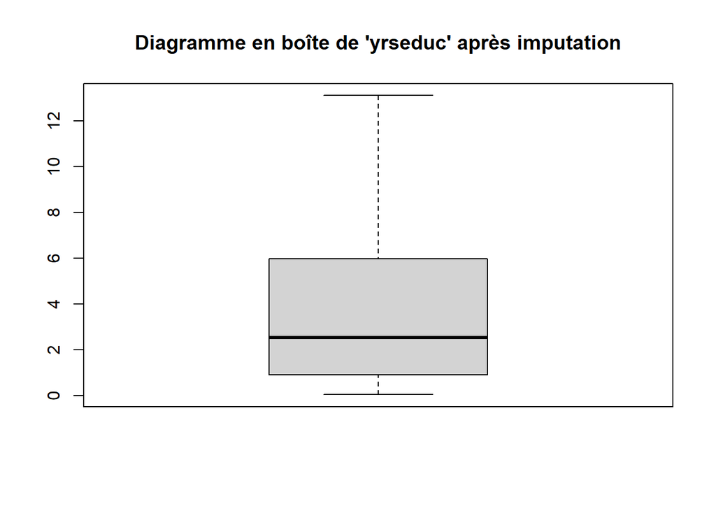

```r
boxplot(completedData$yrseduc, main = "Diagramme en boîte de 'yrseduc' après imputation")
```

```r
# Vérification de la cohérence de l'imputation spécifique et générale
numero_ligne <- 10
valeur_imputee_avant <- if(is.na(data_original$yrseduc[numero_ligne])) "NA" else data_original$yrseduc[numero_ligne]
valeur_imputee_apres <- completedData$yrseduc[numero_ligne]
print(paste("Valeur de 'yrseduc' à la ligne", numero_ligne, "avant imputation :", valeur_imputee_avant))
```

```
## [1] "Valeur de 'yrseduc' à la ligne 10 avant imputation : NA"
```

```r
print(paste("Valeur de 'yrseduc' à la ligne", numero_ligne, "après imputation :", valeur_imputee_apres))
```

```
## [1] "Valeur de 'yrseduc' à la ligne 10 après imputation : 0.31999999"
```

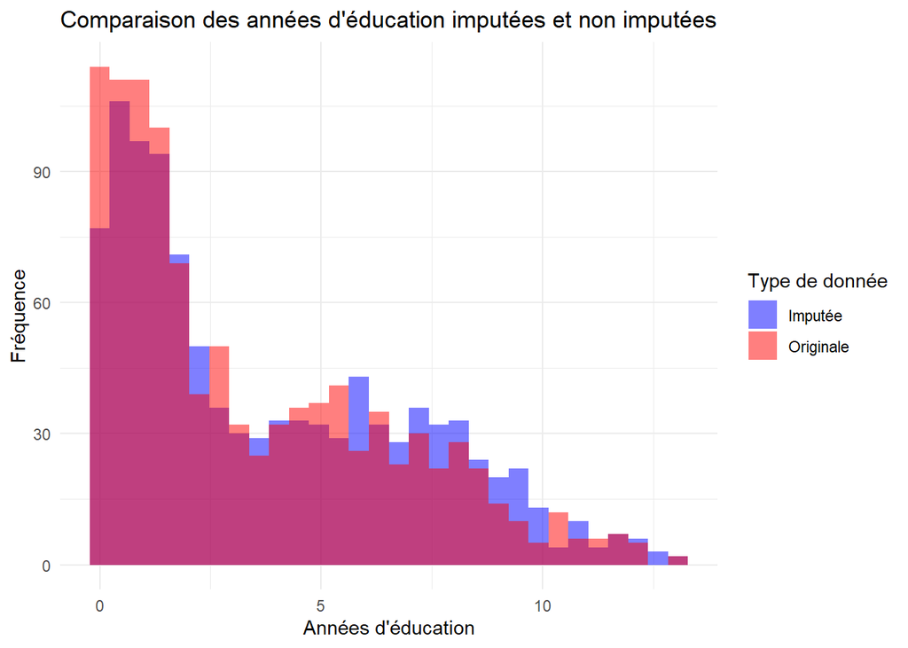

```r
# Création d'une colonne pour indiquer les valeurs imputées pour 'yrseduc'
completedData$imputed_yrseduc <- is.na(data_original$yrseduc) & !is.na(completedData$yrseduc)
completedData$imputed_yrseduc <- as.factor(completedData$imputed_yrseduc)

# Comparaison des distributions des valeurs imputées et non imputées
ggplot(completedData, aes(x = yrseduc, fill = imputed_yrseduc)) +
  geom_histogram(position = "identity", alpha = 0.5, bins = 30) +
  scale_fill_manual(values = c("TRUE" = "red", "FALSE" = "blue"), labels = c("Imputée", "Originale")) +
  labs(title = "Comparaison des années d'éducation imputées et non imputées",
       x = "Années d'éducation",
       y = "Fréquence",
       fill = "Type de donnée") +
  theme_minimal()
```

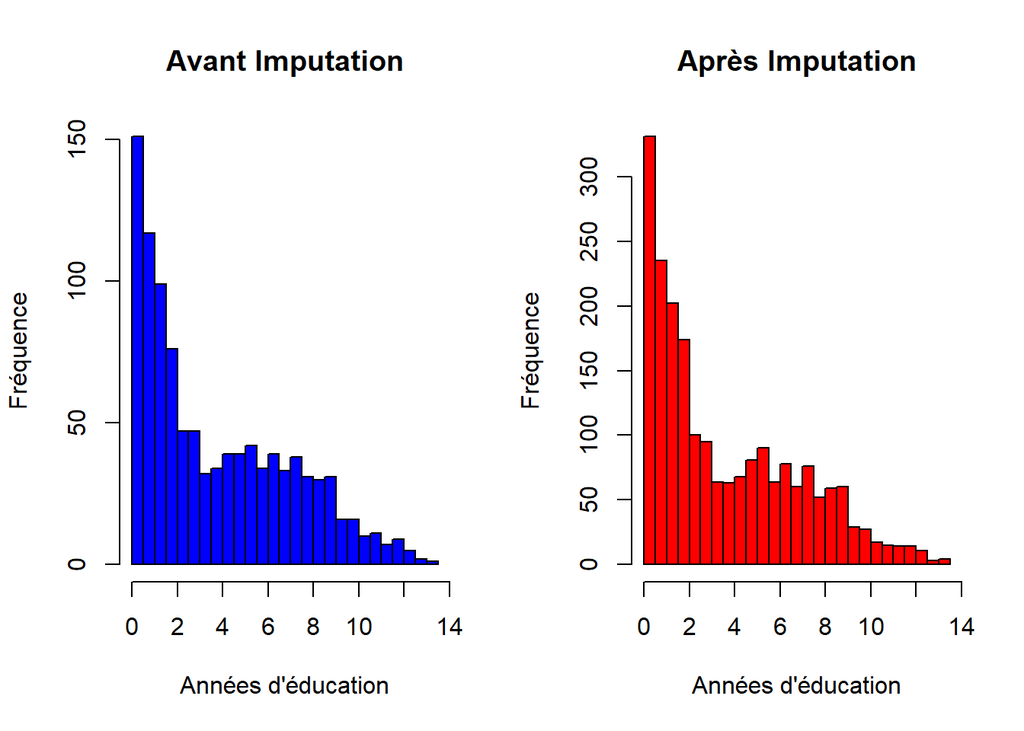

```r
# Comparaison visuelle des distributions avant et après l'imputation
par(mfrow = c(1, 2))
hist(data_original$yrseduc, main = "Avant Imputation", xlab = "Années d'éducation", ylab = "Fréquence", col = "blue", breaks = 30)
hist(completedData$yrseduc, main = "Après Imputation", xlab = "Années d'éducation", ylab = "Fréquence", col = "red", breaks = 30)
```

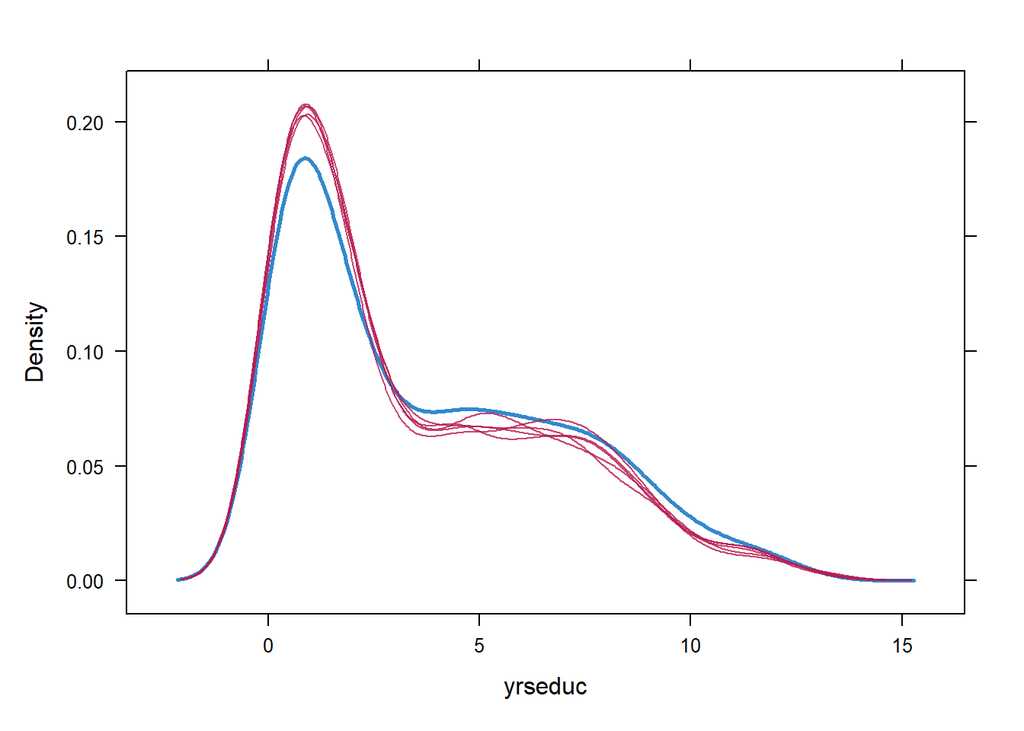

```r
par(mfrow = c(1, 1))

# Aperçu rapide des données imputées et vérification de la convergence
densityplot(imp)
```

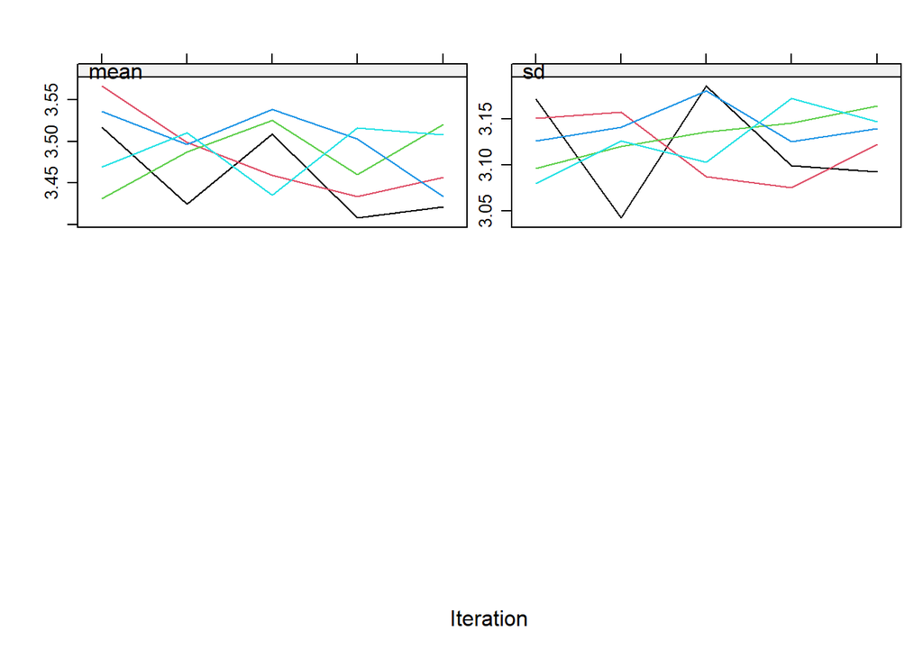

```r
plot(imp, which = "yrseduc")
```

# Évaluation de la qualité de l’imputation et de son impact sur l’intégrité des données

L’analyse des données post-imputation révèle une conservation notable de l’intégrité structurelle et des propriétés statistiques fondamentales de l’ensemble des données. Aucune altération significative des dimensions de l’ensemble de données n’a été constatée suite à l’imputation, ce qui suggère que les valeurs manquantes ont été comblées de manière judicieuse, sans introduire de redondances ou de doublons.

En effet, les statistiques descriptives avant et après l’imputation montrent une conservation des tendances centrales, ce qui suggère que les caractéristiques essentielles des données n’ont pas été altérées de manière significative. Cette constance se manifeste également dans les distributions des années d’éducation, comme illustré par les histogrammes et le diagramme en boîte fournis.

[output not shown]

| **8. Vérification de la cohérence des valeurs imputées avec d’autres variables** |
| --- |

```r
# Régression linéaire simple avant et après imputation
## Avant imputation
lm_before_yrseduc <- lm(yrseduc ~ SES + gdppc, data = data_original)
summary(lm_before_yrseduc)
```

```
##
## Call:
## lm(formula = yrseduc ~ SES + gdppc, data = data_original)
##
## Residuals:
##     Min      1Q  Median      3Q     Max
## -5.1025 -1.2802 -0.3652  1.1904  5.8015
##
## Coefficients:
##               Estimate Std. Error t value Pr(>|t|)
## (Intercept) -5.914e-01  1.378e-01  -4.291 1.95e-05 ***
## SES          5.830e-02  2.397e-03  24.324  < 2e-16 ***
## gdppc        1.848e-04  6.917e-06  26.715  < 2e-16 ***
## ---
## Signif. codes:  0 '***' 0.001 '**' 0.01 '*' 0.05 '.' 0.1 ' ' 1
##
## Residual standard error: 1.758 on 1033 degrees of freedom
##   (1050 observations deleted due to missingness)
## Multiple R-squared:  0.7028, Adjusted R-squared:  0.7023
## F-statistic:  1222 on 2 and 1033 DF,  p-value: < 2.2e-16
```

```r
## Après imputation
lm_after_yrseduc <- lm(yrseduc ~ SES + gdppc, data = completedData)
summary(lm_after_yrseduc)
```

```
##
## Call:
## lm(formula = yrseduc ~ SES + gdppc, data = completedData)
##
## Residuals:
##     Min      1Q  Median      3Q     Max
## -9.1535 -1.3312 -0.1953  1.1613  5.9444
##
## Coefficients:
##               Estimate Std. Error t value Pr(>|t|)
## (Intercept) -8.006e-01  1.017e-01  -7.875 5.44e-15 ***
## SES          6.500e-02  1.755e-03  37.029  < 2e-16 ***
## gdppc        1.373e-04  4.078e-06  33.676  < 2e-16 ***
## ---
## Signif. codes:  0 '***' 0.001 '**' 0.01 '*' 0.05 '.' 0.1 ' ' 1
##
## Residual standard error: 1.838 on 2083 degrees of freedom
## Multiple R-squared:  0.6624, Adjusted R-squared:  0.6621
## F-statistic:  2044 on 2 and 2083 DF,  p-value: < 2.2e-16
```

```r
# Tests d'interaction pour examiner les effets combinés des variables
## Avant imputation
interaction_before <- lm(yrseduc ~ SES * gdppc, data = data_original)
summary(interaction_before)
```

```
##
## Call:
## lm(formula = yrseduc ~ SES * gdppc, data = data_original)
##
## Residuals:
##     Min      1Q  Median      3Q     Max
## -4.3023 -1.2354 -0.3421  1.1110  5.4173
##
## Coefficients:
##               Estimate Std. Error t value Pr(>|t|)
## (Intercept) -1.371e+00  1.511e-01  -9.078   <2e-16 ***
## SES          6.581e-02  2.392e-03  27.505   <2e-16 ***
## gdppc        7.327e-04  5.305e-05  13.813   <2e-16 ***
## SES:gdppc   -6.160e-06  5.917e-07 -10.410   <2e-16 ***
## ---
## Signif. codes:  0 '***' 0.001 '**' 0.01 '*' 0.05 '.' 0.1 ' ' 1
##
## Residual standard error: 1.673 on 1032 degrees of freedom
##   (1050 observations deleted due to missingness)
## Multiple R-squared:  0.7311, Adjusted R-squared:  0.7303
## F-statistic: 935.1 on 3 and 1032 DF,  p-value: < 2.2e-16
```

```r
## Après imputation
interaction_after <- lm(yrseduc ~ SES * gdppc, data = completedData)
summary(interaction_after)
```

```
##
## Call:
## lm(formula = yrseduc ~ SES * gdppc, data = completedData)
##
## Residuals:
##      Min       1Q   Median       3Q      Max
## -11.2957  -1.3066  -0.1863   1.1547   5.8149
##
## Coefficients:
##               Estimate Std. Error t value Pr(>|t|)
## (Intercept) -1.057e+00  1.112e-01  -9.507  < 2e-16 ***
## SES          6.809e-02  1.831e-03  37.184  < 2e-16 ***
## gdppc        3.142e-04  3.238e-05   9.703  < 2e-16 ***
## SES:gdppc   -2.106e-06  3.825e-07  -5.504 4.16e-08 ***
## ---
## Signif. codes:  0 '***' 0.001 '**' 0.01 '*' 0.05 '.' 0.1 ' ' 1
##
## Residual standard error: 1.825 on 2082 degrees of freedom
## Multiple R-squared:  0.6673, Adjusted R-squared:  0.6668
## F-statistic:  1392 on 3 and 2082 DF,  p-value: < 2.2e-16
```

```r
# Analyse en composantes principales après imputation (données complètes requises)
pca_after <- prcomp(completedData[, c("yrseduc", "SES", "gdppc")], scale. = TRUE, na.action = na.omit)
print(summary(pca_after))
```

```
## Importance of components:
##                           PC1    PC2     PC3
## Standard deviation     1.4737 0.7827 0.46427
## Proportion of Variance 0.7239 0.2042 0.07185
## Cumulative Proportion  0.7239 0.9282 1.00000
```

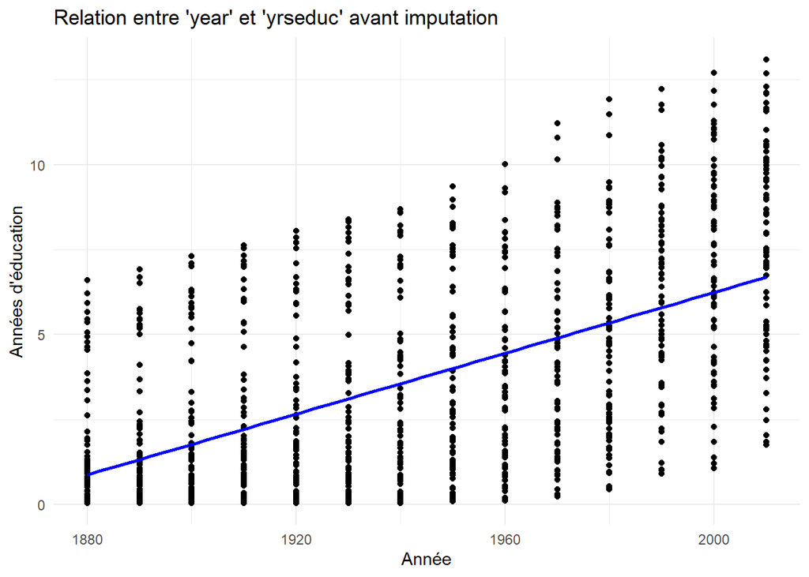

```r
# Tendances annuelles pour 'yrseduc'
### Avant imputation
ggplot(data_original, aes(x = year, y = yrseduc)) +
  geom_point() +
  geom_smooth(method = "lm", se = FALSE, color = "blue") +
  labs(title = "Relation entre 'year' et 'yrseduc' avant imputation", x = "Année", y = "Années d'éducation") +
  theme_minimal()
```

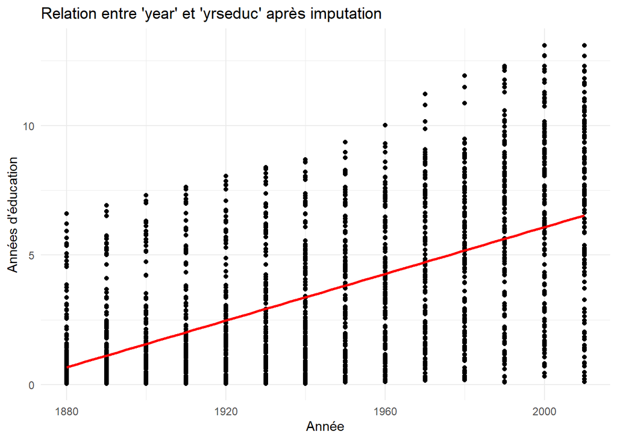

```r
### Après imputation
ggplot(completedData, aes(x = year, y = yrseduc)) +
  geom_point() +
  geom_smooth(method = "lm", se = FALSE, color = "red") +
  labs(title = "Relation entre 'year' et 'yrseduc' après imputation", x = "Année", y = "Années d'éducation") +
  theme_minimal()
```

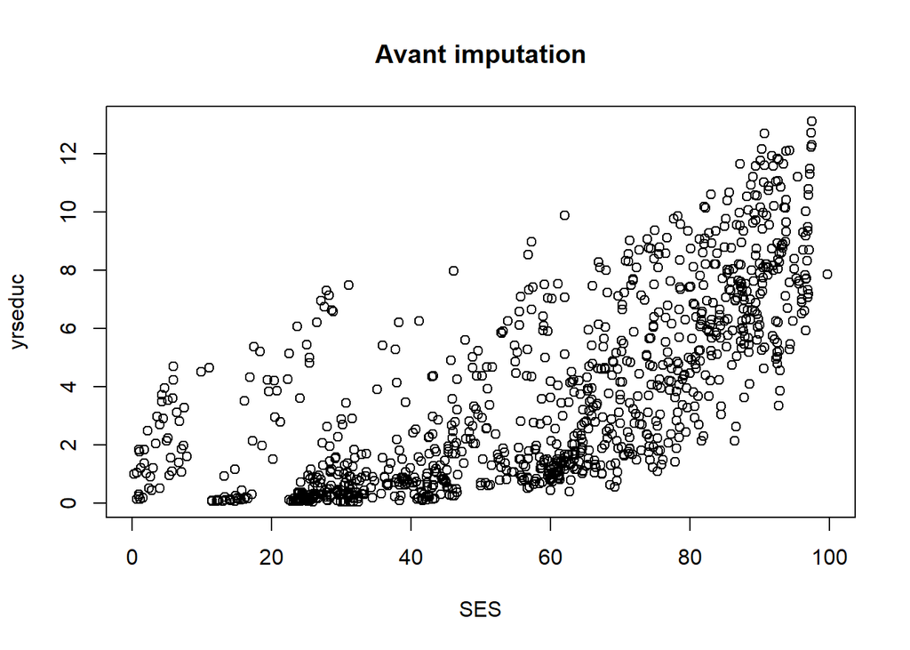

```r
# Graphiques de dispersion pour 'yrseduc' par rapport à 'SES' et 'gdppc'
### Avant imputation
plot(data_original$SES, data_original$yrseduc, main = "Avant imputation", xlab = "SES", ylab = "yrseduc")
```

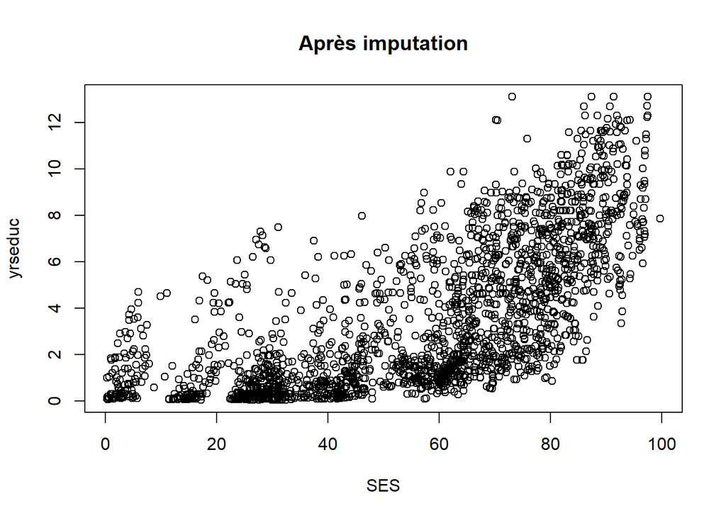

```r
### Après imputation
plot(completedData$SES, completedData$yrseduc, main = "Après imputation", xlab = "SES", ylab = "yrseduc")
```

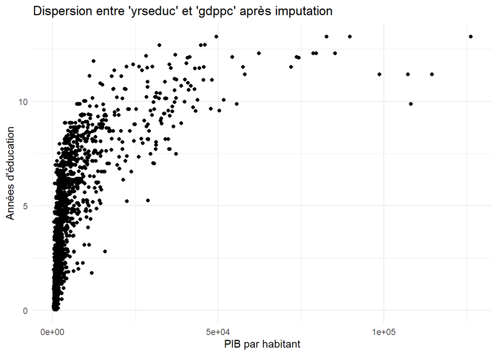

```r
### Dispersion entre 'yrseduc' et 'gdppc' après imputation
ggplot(completedData, aes(x = gdppc, y = yrseduc)) +
  geom_point() +
  labs(title = "Dispersion entre 'yrseduc' et 'gdppc' après imputation", x = "PIB par habitant", y = "Années d'éducation") +
  theme_minimal()
```

# Conservation de l’intégrité des données : Analyse de la cohérence avant et après imputation

La continuité observée dans les graphiques de dispersion avant et après l’imputation renforce cette constatation. Les tendances linéaires entre ‘year’ et ‘yrseduc’ demeurent intactes, avec une augmentation constante des années d’éducation au fil du temps, démontrant que l’imputation n’a pas perturbé la relation temporelle. De même, la dispersion entre ‘yrseduc’ et ‘SES’ ainsi qu’entre ‘yrseduc’ et ‘gdppc’ reste cohérente, indiquant que les dynamiques socioéconomiques fondamentales restent représentatives après l’imputation.

En résumé, l’ensemble des résultats appuie la qualité de l’imputation effectuée, qui parvient à combler les lacunes informationnelles tout en préservant les propriétés statistiques essentielles de l’ensemble de données. Cette conservation de l’intégrité des données assure que les analyses subséquentes, qu’elles visent à explorer des relations causales, à construire des modèles prédictifs ou à tester des hypothèses spécifiques, restent fiables et représentatives des véritables dynamiques étudiées.

| **9. Analyse de la variation des estimations entre différentes complétions** |
| --- |

```r
# Imputer les données avec différentes méthodes
imp_pmm <- mice(data_original, method = 'pmm', m = 5)
imp_mean <- mice(data_original, method = 'mean', m = 5)
# Récupérer les données imputées pour chaque méthode
completedData_pmm <- complete(imp_pmm, action = 1)
completedData_mean <- complete(imp_mean, action = 1)

# Ajuster les modèles de régression sur les données imputées
lm_imputed_pmm <- lm(yrseduc ~ SES + gdppc, data = completedData_pmm)
lm_imputed_mean <- lm(yrseduc ~ SES + gdppc, data = completedData_mean)

# Comparaison des estimations et des intervalles de confiance
print("Résumé du modèle après imputation PMM :")
```

```
## [1] "Résumé du modèle après imputation PMM :"
```

```r
summary(lm_imputed_pmm)
```

```
##
## Call:
## lm(formula = yrseduc ~ SES + gdppc, data = completedData_pmm)
##
## Residuals:
##      Min       1Q   Median       3Q      Max
## -10.5817  -1.3469  -0.2128   1.2140   5.9090
##
## Coefficients:
##               Estimate Std. Error t value Pr(>|t|)
## (Intercept) -7.516e-01  1.028e-01  -7.312 3.74e-13 ***
## SES          6.451e-02  1.775e-03  36.343  < 2e-16 ***
## gdppc        1.374e-04  4.123e-06  33.320  < 2e-16 ***
## ---
## Signif. codes:  0 '***' 0.001 '**' 0.01 '*' 0.05 '.' 0.1 ' ' 1
##
## Residual standard error: 1.858 on 2083 degrees of freedom
## Multiple R-squared:  0.6557, Adjusted R-squared:  0.6554
## F-statistic:  1984 on 2 and 2083 DF,  p-value: < 2.2e-16
```

```r
print("Résumé du modèle après imputation par la moyenne :")
```

```
## [1] "Résumé du modèle après imputation par la moyenne :"
```

```r
summary(lm_imputed_mean)
```

```
##
## Call:
## lm(formula = yrseduc ~ SES + gdppc, data = completedData_mean)
##
## Residuals:
##     Min      1Q  Median      3Q     Max
## -7.5309 -1.3326 -0.1142  1.2651  6.4216
##
## Coefficients:
##              Estimate Std. Error t value Pr(>|t|)
## (Intercept) 1.358e+00  1.031e-01   13.18   <2e-16 ***
## SES         3.744e-02  1.780e-03   21.04   <2e-16 ***
## gdppc       5.719e-05  4.134e-06   13.83   <2e-16 ***
## ---
## Signif. codes:  0 '***' 0.001 '**' 0.01 '*' 0.05 '.' 0.1 ' ' 1
##
## Residual standard error: 1.863 on 2083 degrees of freedom
## Multiple R-squared:  0.327,  Adjusted R-squared:  0.3263
## F-statistic:   506 on 2 and 2083 DF,  p-value: < 2.2e-16
```

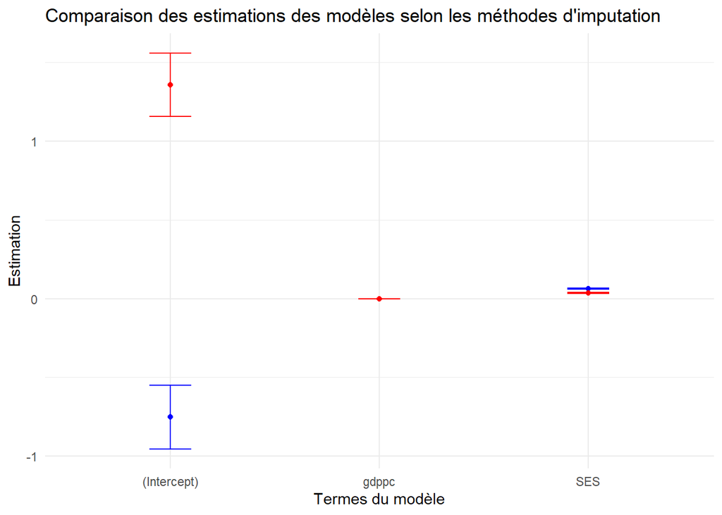

```r
# Préparer les données pour la visualisation
coef_summary_pmm <- summary(lm_imputed_pmm)$coefficients
coef_summary_mean <- summary(lm_imputed_mean)$coefficients

coef_df <- data.frame(
  Term = rownames(coef_summary_pmm),
  Estimate_PMM = coef_summary_pmm[, "Estimate"],
  StdErr_PMM = coef_summary_pmm[, "Std. Error"],
  Estimate_Mean = coef_summary_mean[, "Estimate"],
  StdErr_Mean = coef_summary_mean[, "Std. Error"]
)

# Visualiser l'impact des méthodes d'imputation sur les estimations
plot_imputation_methods <- ggplot(coef_df, aes(x = Term)) +
  geom_point(aes(y = Estimate_PMM), color = "blue") +
  geom_point(aes(y = Estimate_Mean), color = "red") +
  geom_errorbar(aes(ymin = Estimate_PMM - 1.96 * StdErr_PMM,
                    ymax = Estimate_PMM + 1.96 * StdErr_PMM), width = 0.2, color = "blue") +
  geom_errorbar(aes(ymin = Estimate_Mean - 1.96 * StdErr_Mean,
                    ymax = Estimate_Mean + 1.96 * StdErr_Mean), width = 0.2, color = "red") +
  labs(title = "Comparaison des estimations des modèles selon les méthodes d'imputation",
       y = "Estimation", x = "Termes du modèle") +
  theme_minimal()

print(plot_imputation_methods)
```

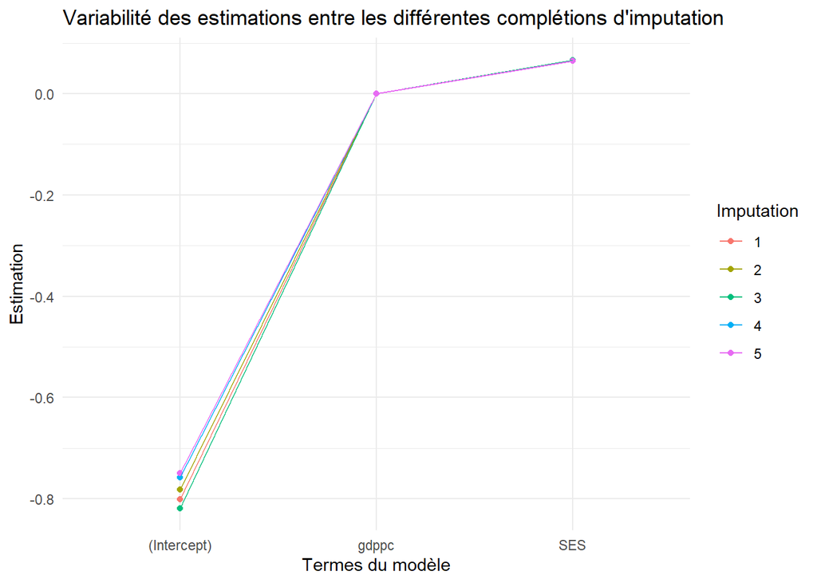

```r
# Extraire et stocker les estimations de chaque imputation
estimates_list <- list()
for(i in 1:5) {
  completed_data <- complete(imp, action = i)
  model <- lm(yrseduc ~ SES + gdppc, data = completed_data)
  estimates_list[[i]] <- summary(model)$coefficients
}

# Transformer la liste des estimations en un dataframe
estimates_df <- do.call(rbind, lapply(1:5, function(i) {
  est <- as.data.frame(estimates_list[[i]])
  est$Imputation <- i
  est$Term <- rownames(estimates_list[[i]])
  return(est)
}))
estimates_df <- reshape2::melt(estimates_df, id.vars = c("Imputation", "Term"),
                               variable.name = "Statistic", value.name = "Value")

# Créer un graphique pour visualiser la variabilité des estimations
plot_imputation_variations <- ggplot(estimates_df[estimates_df$Statistic == "Estimate", ],
                                     aes(x = Term, y = Value, group = Imputation,
                                         color = as.factor(Imputation))) +
  geom_point() +
  geom_line() +
  theme_minimal() +
  labs(title = "Variabilité des estimations entre les différentes complétions d'imputation",
       x = "Termes du modèle",
       y = "Estimation",
       color = "Imputation")

print(plot_imputation_variations)
```

# Évaluation de la stabilité des estimations à travers différentes méthodes d’imputation

Les analyses graphique et statistique démontrent l’impact de diverses méthodes d’imputation sur les estimations de coefficients au sein de modèles de régression linéaire.

**Analyse graphique des estimations des modèles**

La première représentation graphique, illustrant les estimations des coefficients post-imputation par PMM (en bleu) et par la moyenne (en rouge), révèle l’estimation ponctuelle des coefficients de chaque terme du modèle, accompagnée des intervalles de confiance correspondants. L’intercept négatif issu de l’imputation PMM indique la tendance de la ligne de régression dans l’espace théorique où ‘SES’ et ‘gdppc’ seraient à zéro, une condition non observée dans le jeu de données réel. Cet aspect du modèle linéaire, bien qu’il semble contre-intuitif, est une extrapolation qui dépasse le domaine pratique des données. L’accent doit être mis sur les coefficients des prédicteurs qui fournissent une compréhension de la relation entre les variables, tandis que l’intercept, dans ce cas, sert à ajuster la régression sans porter de signification directe quant aux années d’éducation réelles. Autrement dit, cet intercept négatif est une conséquence mathématique de l’ajustement de la régression linéaire aux données et ne doit pas être interprété littéralement.

Le graphique dépeint une remarquable constance dans les estimations des coefficients pour ‘gdppc’ et ‘SES’ à travers cinq imputations différentes, soulignant ainsi la robustesse de la méthode d’imputation et la fiabilité des relations modélisées entre les variables. La proximité des lignes entre les itérations d’imputation confirme que l’effet de ‘gdppc’ et ‘SES’ sur les années d’éducation reste stable, renforçant la validité des analyses subséquentes basées sur ces données imputées.

**Synthèse des modèles de régression**

Le modèle utilisant la technique PMM révèle un R² ajusté de 65.54%, indiquant que presque deux tiers de la variabilité de ‘yrseduc’ sont expliqués par les variables ‘SES’ et ‘gdppc’. Cette forte corrélation démontre l’efficacité du modèle PMM à capturer la structure sous-jacente des données. À l’opposé, l’imputation par la moyenne, bien que statistiquement significative, montre un R² ajusté de 32.63%, reflétant une compréhension moins complète de la dynamique de ‘yrseduc’. Cette différence substantielle suggère que les nuances dans la distribution des données, préservées par PMM, jouent un rôle crucial dans la précision du modèle et que la méthode d’imputation peut affecter la capacité prédictive du modèle et potentiellement orienter les décisions politiques ou éducatives basées sur ces analyses.

**Implications des résultats**

Les résultats de l’analyse révèlent que l’imputation PMM mène à des coefficients plus élevés par rapport à l’imputation par la moyenne, soulignant l’importance accrue des variables ‘SES’ et ‘gdppc’ dans la prédiction de ‘yrseduc’. De plus, la constance des coefficients à travers différentes séries d’imputation illustre la stabilité du modèle PMM, suggérant que les résultats sont peu sensibles aux variations spécifiques de l’imputation. Ce niveau de cohérence indique que l’imputation PMM est capable de préserver la structure sous-jacente des données originales, offrant ainsi une représentation fidèle des relations entre les variables. En conséquence, le choix de l’imputation PMM se révèle judicieux pour l’analyse des données, permettant des estimations robustes et des interprétations fiables des relations modélisées, essentielles pour une prise de décision éclairée.

| **10. Validation croisée** |
| --- |

```r
# Assurer la reproductibilité
set.seed(123)

# Créer un ensemble de données avec 100 valeurs manquantes aléatoires pour 'yrseduc' pour la validation
# Exclure les lignes où 'yrseduc' est déjà NA avant de sélectionner les indices pour la validation
valid_indices <- which(!is.na(data_original$yrseduc)) # Indices des lignes où 'yrseduc' n'est pas NA
missing_indices <- sample(valid_indices, size = 100) # Sélectionner aléatoirement 100 indices parmi les valeurs non-NA
data_with_held <- data_original # Créer une copie des données d'origine
data_with_held$yrseduc[missing_indices] <- NA # Introduire des valeurs NA à ces indices

# Imputer les données manquantes avec MICE
mice_params <- mice(data_with_held, m = 1, maxit = 5, method = 'pmm', seed = 123)
completed_data_with_held <- complete(mice_params)

# Comparer les valeurs réelles et imputées pour 'yrseduc'
original_values <- data_original$yrseduc[missing_indices] # Extraire les valeurs originales devenues NA
imputed_values <- completed_data_with_held$yrseduc[missing_indices] # Extraire les valeurs imputées correspondantes

# Créer un dataframe de comparaison et l'afficher
comparison <- data.frame(Original = original_values, Imputed = imputed_values)
print(comparison)
```

```
##     Original Imputed
## 1     2.3690  6.5693
## 2    10.8732 11.5820
## 3     0.6000  0.0800
## 4     5.3648  4.4628
## 5     2.1300  2.7900
## 6     0.4100  0.5203
## 7     0.7900  0.7500
## 8     1.3200  3.3700
## 9     2.2089  1.8000
## 10    2.2500  1.3600
## 11    0.8200  1.1600
## 12    6.4900  4.4700
## 13    1.6900  1.0600
## 14    0.8300  0.3100
```

[output cut: 86 more lines]

```r
# Calculer les métriques d'évaluation : Erreur quadratique moyenne (MSE) et Erreur absolue moyenne (MAE)
mse <- mean((original_values - imputed_values)^2, na.rm = TRUE)
mae <- mean(abs(original_values - imputed_values), na.rm = TRUE)

# Afficher les métriques d'évaluation
cat("Résumé des métriques d'évaluation pour 'yrseduc' :\n")
```

```
## Résumé des métriques d'évaluation pour 'yrseduc' :
```

```r
cat("Erreur quadratique moyenne (MSE) :", mse, "\n")
```

```
## Erreur quadratique moyenne (MSE) : 2.221434
```

```r
cat("Erreur absolue moyenne (MAE) :", mae, "\n")
```

```
## Erreur absolue moyenne (MAE) : 1.111792
```

# Validation croisée dans l’imputation des données manquantes pour les années d’éducation (‘yrseduc’)

**Objectif principal**

L’objectif principal de cette analyse est d’évaluer la performance du modèle d’imputation utilisé pour traiter les valeurs manquantes de la variable ‘yrseduc’. Cette variable est cruciale pour de nombreuses analyses socioéconomiques, en particulier celles liées à l’éducation et au développement humain.

**Approche méthodologique**

La stratégie déployée pour cette évaluation repose sur une méthode de validation croisée, conçue pour estimer la performance du modèle d’imputation. Une procédure de génération artificielle de valeurs manquantes, en dehors des cas de non-réponse existants, a été mise en place afin d’établir un terrain de comparaison objectif entre les valeurs observées et celles restituées par l’imputation PMM.

**Démarche d’imputation et validation**

Après avoir introduit 100 valeurs manquantes artificielles pour “yrseduc”, la méthode d’imputation PMM a été appliquée pour estimer ces valeurs manquantes. Cette méthode d’imputation itérative s’adapte aux nuances et aux distributions des données originales, offrant ainsi des estimations plus précises.

Ensuite, les valeurs réelles (initialement connues) ont été comparées aux valeurs imputées correspondantes. Cette comparaison a permis de calculer des métriques d’évaluation telles que l’Erreur Quadratique Moyenne (MSE) et l’Erreur Absolue Moyenne (MAE), qui indiquent la performance du modèle d’imputation.

**Importance de l’approche**

Cette approche rigoureuse est essentielle pour plusieurs raisons :

```
En excluant les valeurs déjà manquantes, des biais potentiels dans l'évaluation du modèle ont été évités.

La comparaison entre les valeurs réelles et imputées a fourni une mesure objective de la précision du modèle.

Les métriques d'évaluation ont permis de quantifier l'efficacité du modèle d'imputation, ce qui est crucial pour garantir la fiabilité des analyses ultérieures utilisant ces données.
```

**Implications et défis de la validation**

Les métriques dérivées telles que la MSE de 2.221434 et la MAE de 1.111792 éclairent sur la performance du modèle d’imputation :

[output not shown]

Bien que le processus d’imputation ne soit pas parfait, il s’est révélé être une stratégie efficace face aux défis posés par les données manquantes, en particulier dans des scénarios marqués par des disparités socioéconomiques, des conflits ou un héritage colonial***. L’utilisation de cette approche rigoureuse a permis de diminuer les biais potentiels et de fournir une image plus représentative et complète du paysage éducatif dans divers contextes mondiaux.

*Une note sur l’identification et la classification des données manquantes*

L’ensemble de données de cette étude présente des absences non aléatoires, désignées sous le terme “Missing Not At Random” (MNAR), principalement dû aux caractéristiques spécifiques des pays d’où proviennent ces données. Ces pays sont souvent marqués par des conditions socioéconomiques difficiles, des historiques de conflits ou des passés coloniaux, influençant directement la disponibilité et la collecte des informations, spécialement celles relatives aux années d’éducation (‘yrseduc’).

En effet, la classification MNAR s’applique car les motifs des données manquantes sont intrinsèquement liés à des variables et à des facteurs non capturées intégralement par les autres variables de l’étude, suggérant que les lacunes ne surviennent pas de manière indépendante ou aléatoire. Cette spécificité impacte les méthodes d’imputation choisies et la manière dont les résultats imputés sont analysés et interprétés, soulignant l’importance d’une approche d’analyse prudente et éclairée pour ces types de données manquantes.

Bien que la méthode du PMM ne remédie pas entièrement aux biais engendrés par des données issues de circonstances non observées ou non enregistrées, cette technique a fourni des estimations valides et adaptées au contexte des données examinées. Son usage a conduit à des découvertes pertinentes et à l’élaboration de conclusions bien fondées et fiables.

| **11. Nettoyage continu** |
| --- |

```r
# Correction de l'encodage des noms de pays et vérification de la consistance des données
completedData <- completedData %>%
  mutate(
    year = as.numeric(as.character(year)), # Conversion de 'year' en numérique
    country = as.factor(country),          # Conversion de 'country' en facteur
    SES = ifelse(SES < 0 | SES > 100, NA, SES),  # Remplacement des valeurs SES hors normes
    gdppc = ifelse(gdppc > 1000000, NA, gdppc),  # Remplacement des valeurs gdppc anormales
    yrseduc = ifelse(yrseduc > 25, NA, yrseduc), # Remplacement des valeurs yrseduc anormales
    popshare = ifelse(popshare < 0 | popshare > 1, NA, popshare) # Correction des valeurs popshare
  )
```

| **12. Analyses statistiques** |
| --- |

```r
# Statistiques descriptives
# Calculer les moyennes par groupe pour 'yrseduc', 'gdppc' et 'SES'
avg_yrseduc_by_country <- aggregate(yrseduc ~ country, data = completedData, FUN = mean)
avg_gdppc_by_country <- aggregate(gdppc ~ country, data = completedData, FUN = mean)
avg_SES_by_country <- aggregate(SES ~ country, data = completedData, FUN = mean)

# Afficher les résultats
print(avg_yrseduc_by_country)
```

```
##                      country   yrseduc
## 1                Afghanistan 0.3304786
## 2                    Albania 3.7866214
## 3                    Algeria 2.1605642
## 4                     Angola 0.6314286
## 5                  Argentina 4.8842786
## 6                    Armenia 4.3963143
## 7                  Australia 8.6543357
## 8                    Austria 6.1415786
## 9                    Bahrain 3.5819714
## 10                Bangladesh 0.5548286
## 11                  Barbados 4.5287143
## 12                   Belgium 6.9381714
## 13                    Belize 5.0252857
## 14                     Benin 0.9828357
```

[output cut: 135 more lines]

```r
print(avg_gdppc_by_country)
```

```
##                      country      gdppc
## 1                Afghanistan   740.5692
## 2                    Albania  2292.7694
## 3                    Algeria  3562.2555
## 4                     Angola  1766.9817
## 5                  Argentina  6627.2605
## 6                    Armenia  2965.1153
## 7                  Australia 12958.9139
## 8                    Austria 11973.8796
## 9                    Bahrain 10085.3773
## 10                Bangladesh   851.3631
## 11                  Barbados  4907.9307
## 12                   Belgium 12451.7346
## 13                    Belize  3260.4002
## 14                     Benin   975.2146
```

[output cut: 135 more lines]

```r
print(avg_SES_by_country)
```

```
##                      country       SES
## 1                Afghanistan 16.740751
## 2                    Albania 67.088287
## 3                    Algeria 47.384224
## 4                     Angola 23.434315
## 5                  Argentina 79.777695
## 6                    Armenia 74.444106
## 7                  Australia 93.911176
## 8                    Austria 84.350974
## 9                    Bahrain 55.486898
## 10                Bangladesh 19.581918
## 11                  Barbados 74.794607
## 12                   Belgium 88.482692
## 13                    Belize 74.429931
## 14                     Benin 20.842572
```

[output cut: 135 more lines]

# Disparités internationales en éducation, PIB et statut socioéconomique

L’analyse des moyennes des années d’éducation, du PIB par habitant et du SES montre des variations significatives entre les pays. Les données indiquent, par exemple, que la Grèce et l’Islande ont des années d’éducation moyennes plus élevées et affichent également des niveaux de SES supérieurs, contrairement au Guatemala et à Haïti, où les moyennes sont plus basses pour ces indicateurs. Cela suggère des différences marquées dans l’accès à l’éducation et dans les conditions économiques entre ces pays. De même, le PIB par habitant reflète la prospérité économique, avec Hong Kong et l’Islande montrant des valeurs élevées, en contraste avec des pays comme le Yemen. Ces variations mettent en lumière la diversité des contextes socioéconomiques à travers le monde.

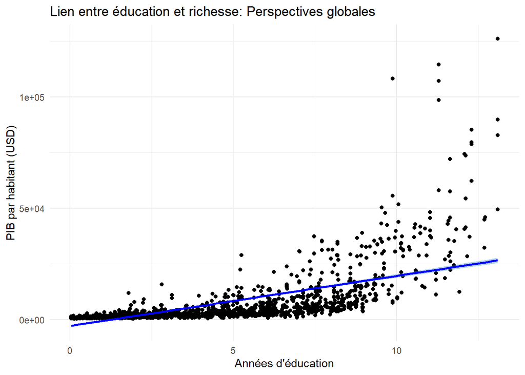

```r
# Exploration des relations entre variables
# Corrélation entre années d'éducation et PIB par habitant
ggplot(completedData, aes(x = yrseduc, y = gdppc)) +
  geom_point() +
  geom_smooth(method = "lm", colour = "blue", fill = "#4292c6") +
  labs(title = "Lien entre éducation et richesse: Perspectives globales",
       x = "Années d'éducation",
       y = "PIB par habitant (USD)") +
  theme_minimal() +
  theme(legend.position = "none")
```

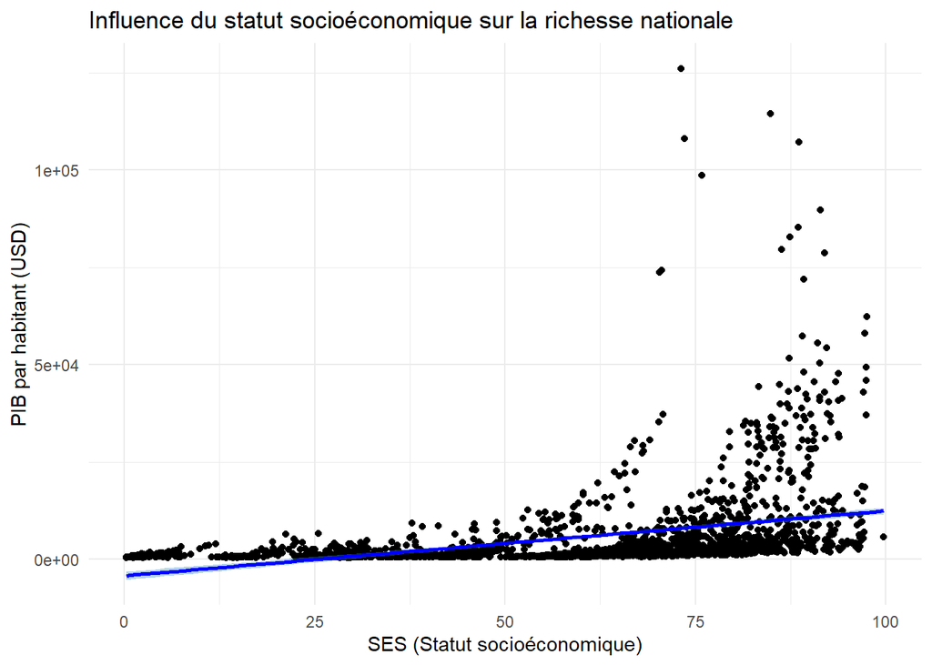

```r
# Corrélation entre SES et PIB par habitant
ggplot(completedData, aes(x = SES, y = gdppc)) +
  geom_point() +
  geom_smooth(method = "lm", colour = "blue", fill = "#4292c6") +
  labs(title = "Influence du statut socioéconomique sur la richesse nationale",
       x = "SES (Statut socioéconomique)",
       y = "PIB par habitant (USD)") +
  theme_minimal() +
  theme(legend.position = "none")
```

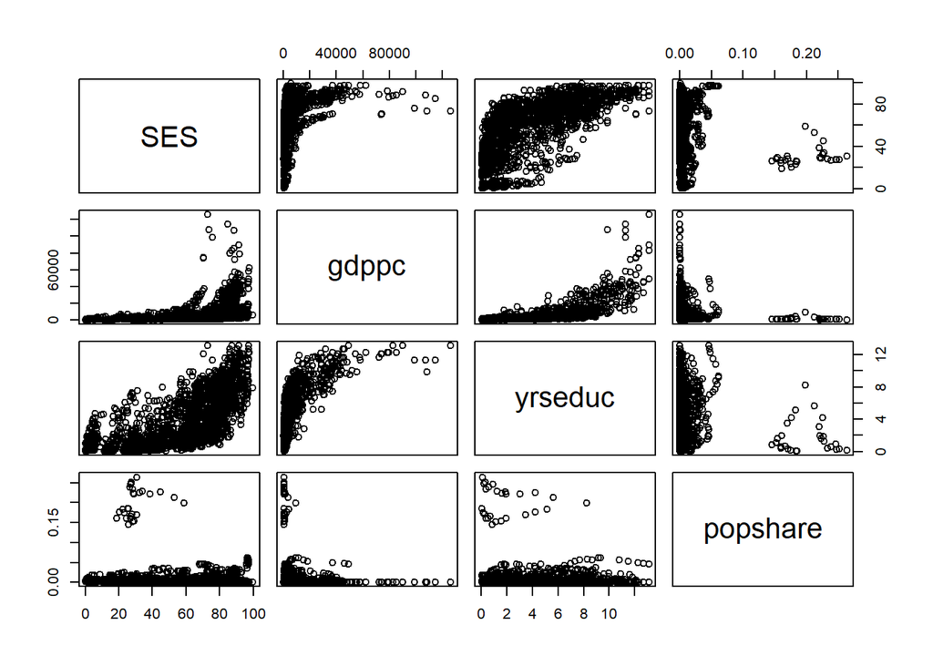

```r
# Matrice de dispersion pour les variables sélectionnées
pairs(completedData[, c("SES", "gdppc", "yrseduc", "popshare")])
```

# Analyse des corrélations et distributions dans le développement socioéconomique global

Cette section décrypte les dynamiques entre les années moyennes d’éducation (yrseduc), le statut socioéconomique (SES) et le produit intérieur brut par habitant (gdppc) pour dresser un portrait du développement socioéconomique à l’échelle globale.

L’analyse de corrélation révèle une association positive entre l’éducation et la prospérité économique, suggérant que l’investissement dans le capital humain est un vecteur de croissance économique. Néanmoins, l’hétérogénéité des données signalée par la dispersion des points de données indique que des facteurs exogènes, tels que la qualité de l’enseignement ou le climat politique, peuvent influer sur cette corrélation. Ces facteurs exogènes, bien qu’ils ne soient pas directement mesurés dans l’analyse actuelle, doivent être pris en compte pour une évaluation approfondie de l’influence de l’éducation sur le développement économique.

La corrélation entre le SES et le gdppc confirme un lien entre le bien-être socioéconomique et la richesse nationale, bien que cette relation soit modérée par d’autres variables socioéconomiques comme la santé publique, les infrastructures et les politiques gouvernementales. Les écarts notables entre les pays révèlent les inégalités régionales et mettent en exergue la variabilité des trajectoires de développement, ce qui appuie la thèse de la nécessité d’approches politiques nuancées et contextualisées.

L’examen des matrices de dispersion entre le SES, le gdppc, yrseduc et la part démographique réaffirme la complexité des interactions socioéconomiques, dépassant la simple causalité entre niveau d’éducation et richesse économique. Les implications de cette étude confirment que des stratégies de développement intégrées, qui englobent diverses facettes socioéconomiques, sont indispensables pour améliorer significativement les conditions de vie au sein de divers cadres nationaux et régionaux.

Cette investigation réitère l’importance de l’éducation en tant que pilier du développement économique, tout en soulignant l’impératif d’intégrer un spectre étendu de variables pour une compréhension holistique et l’optimisation du statut socioéconomique mondial.

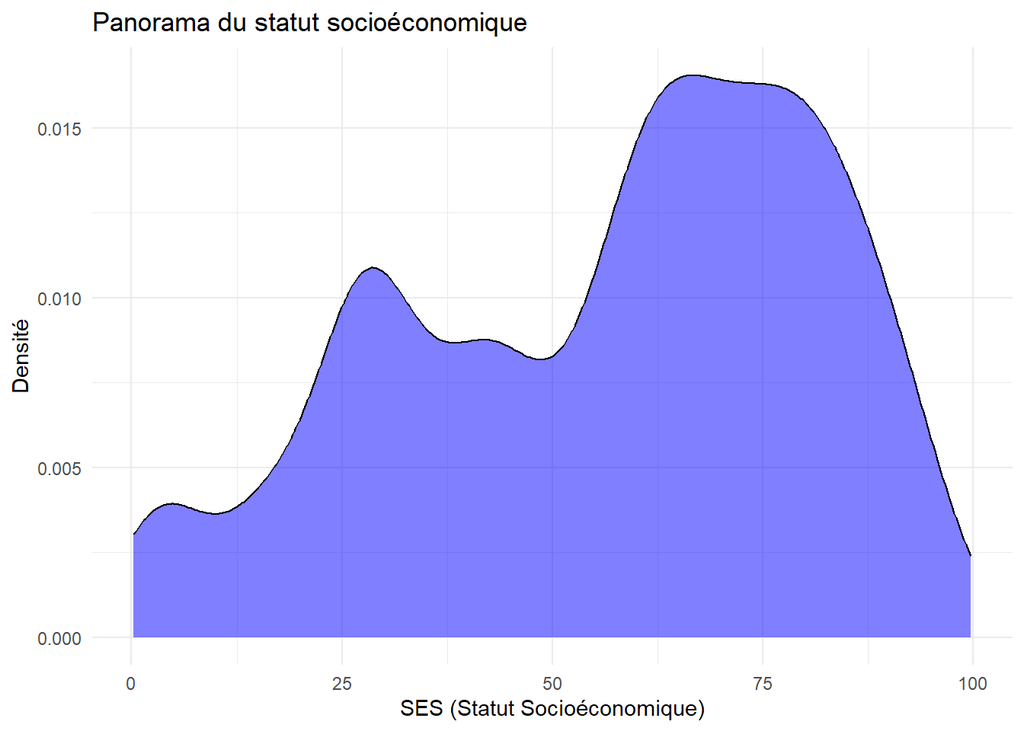

```r
# Exploration des distributions
# Distribution de densité du SES
ggplot(completedData, aes(x = SES)) +
  geom_density(fill = "blue", alpha = 0.5) +
  labs(title = "Panorama du statut socioéconomique",
       x = "SES (Statut Socioéconomique)",
       y = "Densité") +
  theme_minimal()
```

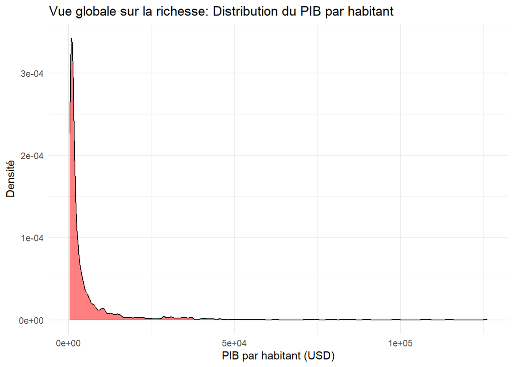

```r
# Distribution de densité du PIB par habitant
ggplot(completedData, aes(x = gdppc)) +
  geom_density(fill = "red", alpha = 0.5) +
  labs(title = "Vue globale sur la richesse: Distribution du PIB par habitant",
       x = "PIB par habitant (USD)",
       y = "Densité") +
  theme_minimal()
```

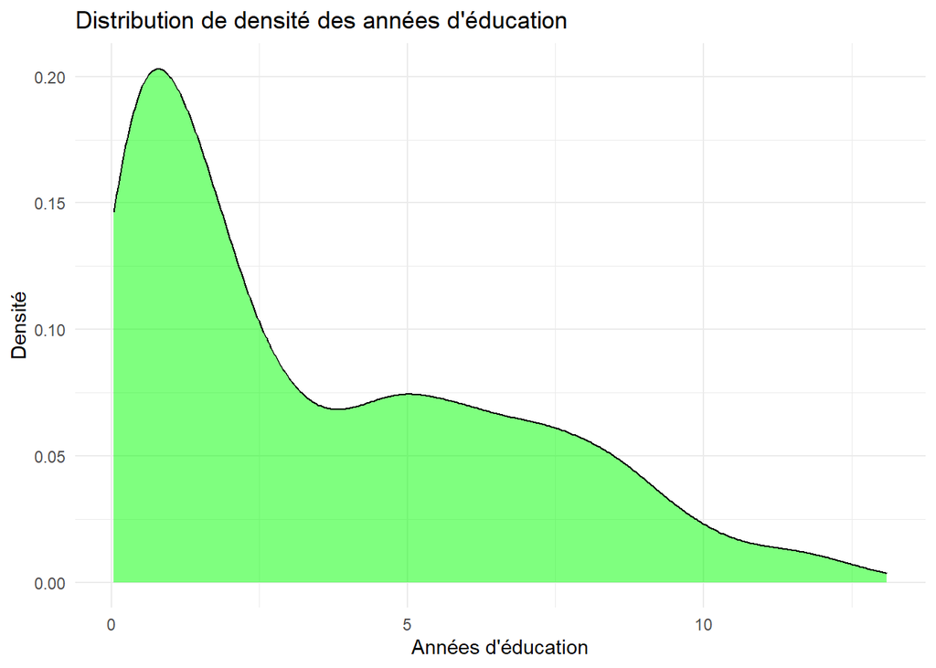

```r
# Distribution de densité pour 'yrseduc'
ggplot(completedData, aes(x = yrseduc)) +
  geom_density(fill = "green", alpha = 0.5) +
  labs(title = "Distribution de densité des années d'éducation",
       x = "Années d'éducation",
       y = "Densité") +
  theme_minimal()
```

# Disparités et dynamiques socioéconomiques : Une analyse globale

L’examen des distributions du SES, du PIB par habitant et des années d’éducation révèle des informations essentielles sur les disparités et les tendances socioéconomiques à l’échelle mondiale.

La distribution du SES montre une distribution bimodale, indiquant la présence de deux groupes distincts de pays selon leur SES. Cela peut refléter une division globale entre les pays développés et les pays en développement. Les pics dans la distribution du SES suggèrent que tandis qu’un groupe de pays bénéficie d’un niveau de vie élevé et d’un bien-être socioéconomique important, un autre groupe reste confronté à des défis économiques et sociaux majeurs.

La distribution du PIB par habitant, quant à elle, présente une forte asymétrie droite, indiquant que la majorité des pays ont un PIB par habitant relativement bas, tandis qu’une petite fraction de pays affiche des niveaux de richesse extrêmement élevés. Cette asymétrie souligne les inégalités économiques mondiales et met en évidence les défis associés à la réalisation d’une croissance économique équitable.

Enfin, la distribution des années d’éducation illustre une tendance significative : une majorité de la population a reçu peu ou pas d’éducation formelle, comme en témoigne le grand pic initial. Cependant, il existe également une proportion notable ayant atteint un niveau d’éducation intermédiaire, reflété par le second pic. La portion étendue vers la droite du graphique indique que moins d’individus atteignent des niveaux d’éducation avancés. Cette distribution pourrait souligner les disparités éducatives existantes et signaler la nécessité de politiques visant à améliorer l’accès et la qualité de l’éducation.

En résumé, l’analyse de ces distributions et tendances offre une compréhension nuancée des dynamiques socioéconomiques mondiales, soulignant les disparités importantes tout en reconnaissant les améliorations générales du bien-être. Ces données peuvent informer les politiques de développement en mettant en évidence les zones nécessitant une attention particulière et en identifiant les facteurs clés de réussite socioéconomique.

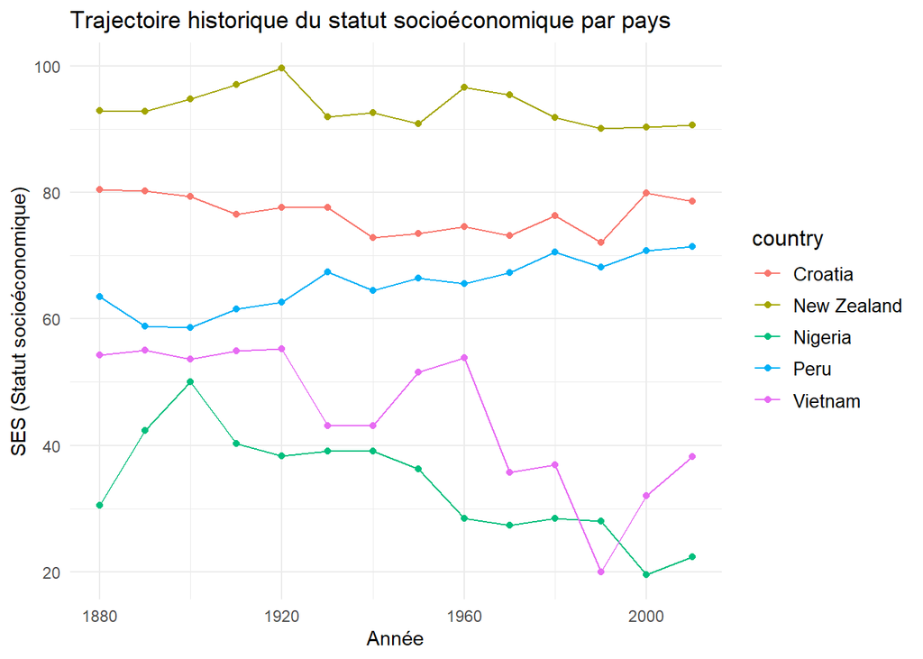

```r
# Exploration des relations entre SES, éducation et temps
# Évolution du SES au fil des années pour les pays sélectionnés
specific_countries <- c("Croatia", "New Zealand", "Nigeria", "Peru", "Vietnam")
filtered_data <- completedData[completedData$country %in% specific_countries, ]

ggplot(filtered_data, aes(x = year, y = SES, color = country)) +
  geom_line() +
  geom_point() +
  labs(title = "Trajectoire historique du statut socioéconomique par pays",
       x = "Année",
       y = "SES (Statut socioéconomique)") +
  theme_minimal() +
  theme(legend.title = element_text(size = 12),
        legend.text = element_text(size = 10))
```

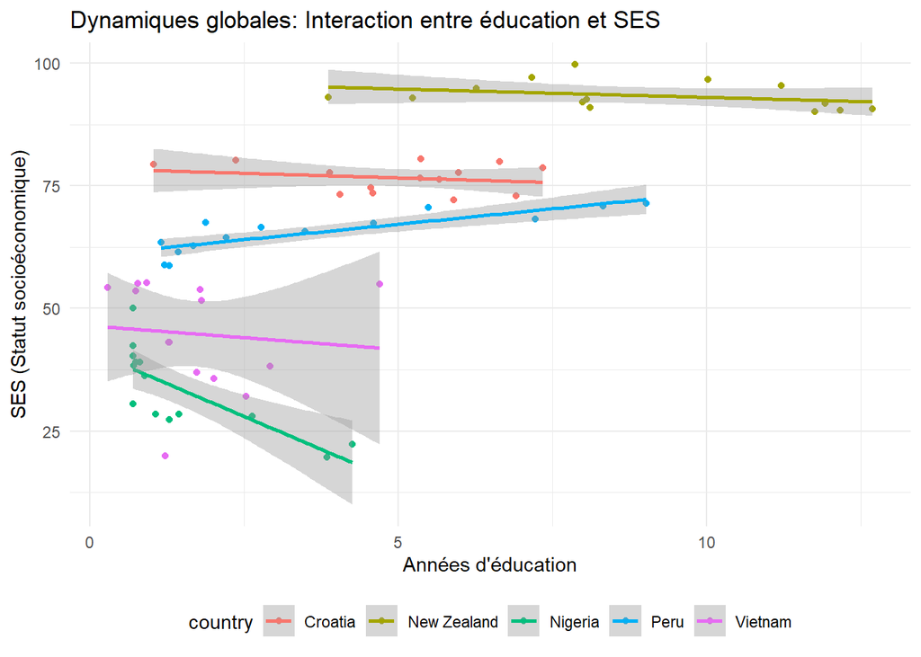

```r
# Interaction entre SES et années d'éducation par pays
ggplot(filtered_data, aes(x = yrseduc, y = SES, color = country)) +
  geom_point() +
  geom_smooth(method = "lm") +
  labs(title = "Dynamiques globales: Interaction entre éducation et SES",
       x = "Années d'éducation",
       y = "SES (Statut socioéconomique)") +
  theme_minimal() +
  theme(legend.position = "bottom")
```

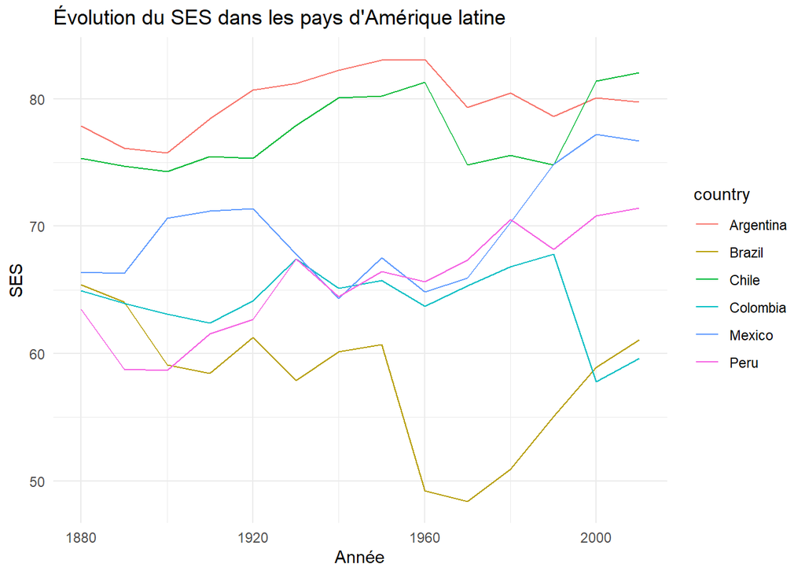

```r
# Comparer des pays de régions similaires ou différentes
# Exemple : Comparer des pays d'Amérique latine
latam_countries <- c("Argentina", "Brazil", "Chile", "Colombia", "Mexico", "Peru")
latam_data <- completedData[completedData$country %in% latam_countries, ]

ggplot(latam_data, aes(x = year, y = SES, color = country)) +
  geom_line() +
  labs(title = "Évolution du SES dans les pays d'Amérique latine",
       x = "Année",
       y = "SES") +
  theme_minimal()
```

```r
# Identifier les pays ayant le plus progressé en termes de SES
first_year <- min(completedData$year, na.rm = TRUE)
last_year <- max(completedData$year, na.rm = TRUE)

SES_variation <- completedData %>%
  group_by(country) %>%
  summarise(SES_first = mean(SES[year == first_year], na.rm = TRUE),
            SES_last = mean(SES[year == last_year], na.rm = TRUE),
            SES_variation = SES_last - SES_first)

SES_variation <- SES_variation[order(-SES_variation$SES_variation), ]
head(SES_variation, 10)
```

```
## # A tibble: 10 × 4
##    country              SES_first SES_last SES_variation
##    <fct>                    <dbl>    <dbl>         <dbl>
##  1 Botswana                  30.2     75.7          45.6
##  2 Gabon                     30.0     74.5          44.4
##  3 Albania                   41.8     74.9          33.1
##  4 Iran                      46.0     76.5          30.5
##  5 South Korea               59.9     89.8          29.9
##  6 Brunei Darussalam         56.7     86.3          29.6
##  7 China                     30.6     59.0          28.3
##  8 United Arab Emirates      61.1     89.1          28.0
##  9 Singapore                 61.6     89.2          27.7
## 10 Hong Kong                 63.0     89.2          26.3
```

# Stratégies de développement et trajectoires socioéconomiques : Une analyse comparative et multisectorielle

Le développement socioéconomique est un processus complexe façonné par de multiples facteurs interdépendants tels que les politiques économiques, l’éducation, la stabilité politique et la gouvernance. Cette analyse se penche sur les relations entre ces éléments en analysant les parcours variés de différents pays. L’objectif est d’identifier les principales tendances et leçons qui peuvent guider l’élaboration de stratégies de développement à la fois efficaces et pérennes.

**Trajectoires du SES et influences historiques**

Les variations du SES sont profondément ancrées dans les transitions politiques, économiques et éducatives propres à chaque pays. Des événements marquants comme la guerre du Vietnam (1955-1975) ont pesé lourdement, avant que des réformes comme le Đổi Mới (Renouveau) au Vietnam ne permettent un redressement socioéconomique grâce à l’ouverture aux marchés internationaux (Fforde & De Vylder 1996, 24-28). Au Pérou, les politiques d’ouverture économique, la réduction des restrictions commerciales et l’investissement dans les infrastructures et le secteur minier ont stimulé la hausse du SES (Vos et al. 2006, 45-51). À l’inverse, des pays comme le Nigeria ont lutté contre l’instabilité politique, la dépendance aux ressources naturelles et la corruption, entravant une progression positive (Sala-i-Martin & Subramanian 2003).

**Lien complexe entre l’éducation et le SES**

L’impact de l’éducation sur le SES n’est pas uniforme. Au Pérou, l’amélioration de l’accès à l’éducation, la construction d’infrastructures scolaires, les programmes d’aide aux familles défavorisées et la valorisation du corps enseignant ont contribué à un lien positif entre l’éducation et le SES (Vega 2005, 32-38). Cependant, la Croatie illustre un cas où une hausse des années d’éducation ne s’est pas systématiquement traduite par une amélioration du SES. Ce constat inhabituel pourrait s’expliquer par un décalage entre les compétences acquises et celles requises sur le marché du travail, les difficultés économiques après 1991 limitant les retombées de l’éducation (Bejaković 2004, 95-102), ou une fuite des cerveaux (OCDE 2018).

**Impact des politiques stratégiques sur le développement socioéconomique**

Le Botswana et la Corée du Sud servent de cas d’étude probants pour démontrer l’influence décisive de politiques économiques bien orientées sur le développement socioéconomique. Le Botswana a capitalisé sur les revenus de son secteur diamantaire pour financer des avancées substantielles en matière d’infrastructures, d’éducation et de santé, posant ainsi les bases d’une économie plus diversifiée et résiliente (Mogalakwe 2017, 136-146 ; Mbuva 2022). Simultanément, la Corée du Sud a misé sur une montée en gamme technologique, l’amélioration des compétences de sa population et le renforcement de secteurs industriels pivots (Lee 2021 ; Lee et al. 2019), des mouvements stratégiques qui ont été les catalyseurs de sa transformation économique et sociale. Ces stratégies ont contribué à modeler des trajectoires de développement durable, établissant un modèle pour d’autres économies aspirant à une croissance similaire.

**Développement socioéconomique et éducation : Une analyse multifacette**

L’analyse des indicateurs économiques en Amérique latine révèle des parcours de développement différenciés, modelés par une combinaison de politiques internes et de facteurs externes.

L’histoire économique de l’Argentine, caractérisée par une alternance entre périodes de prospérité et de récession, débute avec une phase de croissance soutenue grâce à l’agriculture et l’exploitation minière jusqu’aux années 1960 (Lewis 1990). Les politiques protectionnistes et une tentative ratée d’industrialisation par substitution d’importations ont cependant marqué le début d’un ralentissement économique (Gerchunoff et Llach 2005, 319-324). Les années 1970 ont vu une tentative de relance par la demande qui n’a pas su résister à la crise pétrolière et à l’inflation, menant à l’hyperinflation et à la récession de la “décennie perdue” des années 1980 (Di Tella 1983, 135-138 ; Frenkel et Rapetti 2010). La stabilisation temporaire du début des années 1990 grâce à la parité fixe du peso avec le dollar fut rapidement minée par des réformes néolibérales, débouchant sur la crise financière dévastatrice de 2001-2002 (Burdisso et al. 2004, 315-326 ; Mussa 2002). Malgré une reprise économique ultérieure, l’Argentine fait face à des défis macroéconomiques persistants qui l’empêchent de retrouver son ancien niveau de SES (FMI 2022).

De son côté, le Brésil a connu ses propres défis économiques dans les années 1950, marqués par une politique de substitution aux importations et une instabilité politique (Bacha et Greenhill 1992, 35-38). Le changement de régime en 1964 a initié une période de forte croissance, impulsée par l’industrialisation et l’augmentation des exportations. Néanmoins, la crise des années 1980, marquée par des difficultés économiques importantes, a freiné cette élan, conduisant à une phase de récession et d’hyperinflation (Ferreira et al. 2010, 39-45). Malgré cela, le Brésil a connu un redressement remarquable depuis les années 1970, soulignant une amélioration constante des conditions socioéconomiques qui s’est poursuivie malgré les turbulences politiques et économiques (Neri 2022).

Ainsi, le SES de l’Argentine et du Brésil raconte l’histoire de ces nations qui ont navigué à travers des périodes de prospérité ainsi que de défi, chacune façonnée par des décisions politiques clés et des conditions économiques mondiales. Leur parcours souligne la complexité des dynamiques économiques et les répercussions qu’elles peuvent avoir sur la société dans son ensemble.

**Stratégies de développement et progrès socioéconomique**

L’étude présente une analyse approfondie des progrès socioéconomiques réalisés par le Botswana et l’Iran, mettant en évidence l’influence déterminante de la stratégie politique et de la gestion des ressources naturelles sur le développement national. Au Botswana, l’augmentation substantielle du statut socioéconomique, de 30,15 à 75,73, reflète une gestion prudente et stratégique des revenus générés par l’exploitation des diamants (Hillbom 2008, 191-211). Le gouvernement a judicieusement réinvesti ces revenus dans l’amélioration des infrastructures, le système éducatif et les services de santé, tout en s’engageant dans la diversification économique pour atténuer la dépendance aux marchés volatils des ressources naturelles (Lewin 2011, 82-95). Cette politique a permis de poser les fondations d’une économie solide et moins exposée aux fluctuations économiques mondiales.

Malgré les défis géopolitiques et économiques auxquels il a été confronté, notamment les sanctions internationales et la volatilité des prix du pétrole, l’Iran a réussi à considérablement améliorer son SES, passant de 45,95 à 76,49. Cette progression est en grande partie attribuable aux investissements massifs dans les secteurs sociaux tels que l’éducation et les soins de santé publics (Salehi-Isfahani 2022 ; Salehi-Isfahani et al. 2014, 489-501). Le gouvernement iranien a mis l’accent sur l’amélioration de l’accès aux services de base et au développement des capacités humaines. De plus, des efforts ont été déployés pour diversifier l’économie au-delà de la seule dépendance aux exportations pétrolières. Bien que les résultats soient mitigés, ces initiatives ont contribué à réduire la pauvreté, augmenter l’espérance de vie et améliorer le niveau de vie de la population (Farzanegan & Markwardt 2018, 277-289).

```r
# Clustering
# Sélectionner et normaliser les données pour le clustering
data_for_clustering <- select(completedData, yrseduc, SES, gdppc)
data_norm <- as.data.frame(scale(data_for_clustering))

# Effectuer le clustering K-means sur les données normalisées
set.seed(123)  # Pour des résultats reproductibles
kmeans_result <- kmeans(data_norm, centers = 3)

# Ajouter les clusters au dataframe original
completedData$cluster <- kmeans_result$cluster

# Calculer les moyennes pour chaque variable dans chaque cluster
cluster_means <- completedData %>%
  group_by(cluster) %>%
  summarise(
    Avg_yrseduc = mean(yrseduc, na.rm = TRUE),
    Avg_SES = mean(SES, na.rm = TRUE),
    Avg_gdppc = mean(gdppc, na.rm = TRUE)
  )

# Ordonner les clusters selon les moyennes
ordered_clusters <- cluster_means[order(cluster_means$Avg_yrseduc,
                                        cluster_means$Avg_SES,
                                        cluster_means$Avg_gdppc), ]

# Assigner de nouveaux noms de cluster (1, 2, 3) selon l'ordre croissant des moyennes
ordered_clusters$new_cluster <- 1:nrow(ordered_clusters)

# Remplacer les anciens noms de cluster par les nouveaux dans le dataframe original
completedData$cluster <- ordered_clusters$new_cluster[match(completedData$cluster, ordered_clusters$cluster)]

# Vérifier les résultats
cluster_means <- completedData %>%
  group_by(cluster) %>%
  summarise(
    Avg_yrseduc = mean(yrseduc, na.rm = TRUE),
    Avg_SES = mean(SES, na.rm = TRUE),
    Avg_gdppc = mean(gdppc, na.rm = TRUE)
  )

print(cluster_means)
```

```
## # A tibble: 3 × 4
##   cluster Avg_yrseduc Avg_SES Avg_gdppc
##     <int>       <dbl>   <dbl>     <dbl>
## 1       1        1.21    37.6     1150.
## 2       2        5.51    75.3     5139.
## 3       3       10.2     85.9    39668.
```

```r
# Examiner les relations au sein des clusters
for (cluster in unique(completedData$cluster)) {
  cluster_data <- completedData[completedData$cluster == cluster, ]

  print(paste0("Cluster ", cluster, ":"))
  print(paste("Corrélation entre SES et éducation :", cor(cluster_data$SES, cluster_data$yrseduc)))
  print(paste("Corrélation entre SES et PIB par habitant :", cor(cluster_data$SES, cluster_data$gdppc)))
  print(paste("Corrélation entre éducation et PIB par habitant :", cor(cluster_data$yrseduc, cluster_data$gdppc)))
}
```

```
## [1] "Cluster 1:"
## [1] "Corrélation entre SES et éducation : 0.111976134614767"
## [1] "Corrélation entre SES et PIB par habitant : 0.0517590359592831"
## [1] "Corrélation entre éducation et PIB par habitant : 0.544493703840308"
## [1] "Cluster 2:"
## [1] "Corrélation entre SES et éducation : 0.249697080556334"
## [1] "Corrélation entre SES et PIB par habitant : 0.122529474815755"
## [1] "Corrélation entre éducation et PIB par habitant : 0.615520308097399"
## [1] "Cluster 3:"
## [1] "Corrélation entre SES et éducation : 0.502577156219504"
## [1] "Corrélation entre SES et PIB par habitant : -0.0133475775834092"
## [1] "Corrélation entre éducation et PIB par habitant : 0.444397351620344"
```

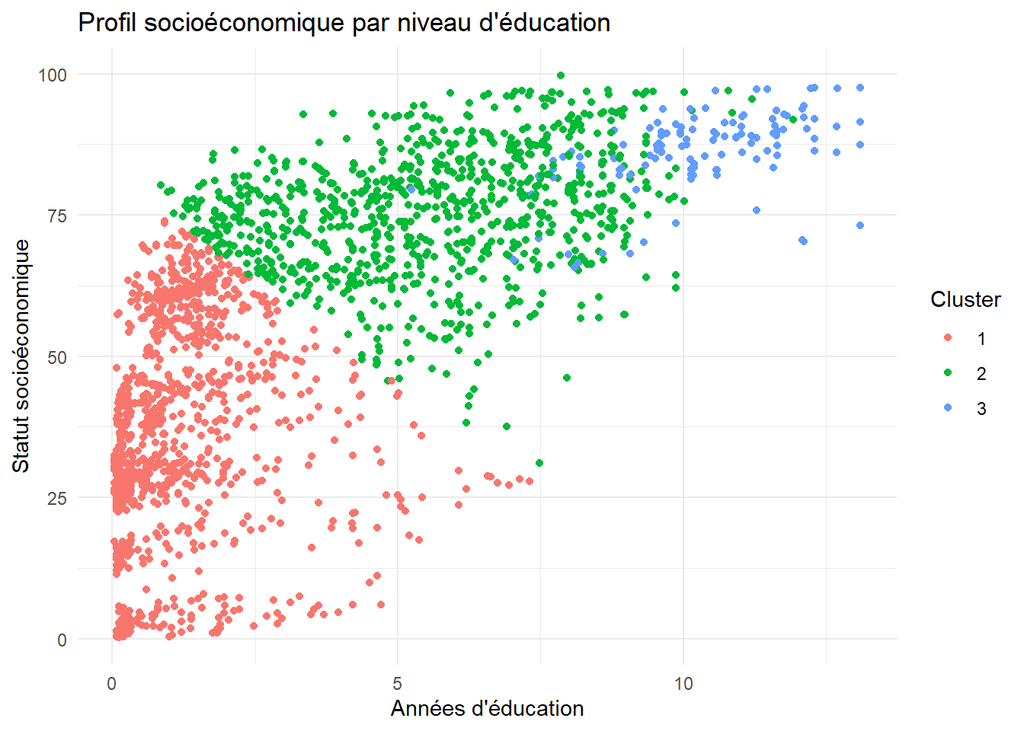

```r
# Visualisation des clusters
# Graphique de dispersion pour années d'éducation vs. SES
ggplot(completedData, aes(x = yrseduc, y = SES, color = factor(cluster))) +
  geom_point() +
  labs(title = "Profil socioéconomique par niveau d'éducation",
       x = "Années d'éducation",
       y = "Statut socioéconomique",
       color = "Cluster") +
  theme_minimal()
```

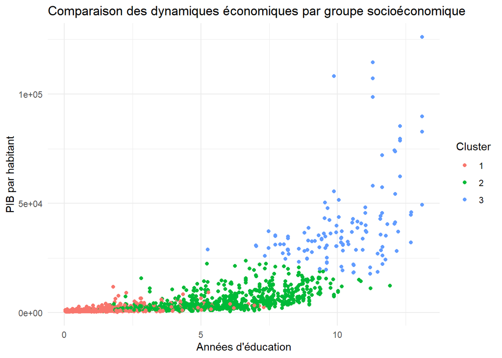

```r
# Graphique de dispersion pour années d'éducation vs. PIB par habitant
ggplot(completedData, aes(x = yrseduc, y = gdppc, color = factor(cluster))) +
  geom_point() +
  labs(title = "Comparaison des dynamiques économiques par groupe socioéconomique",
       x = "Années d'éducation",
       y = "PIB par habitant",
       color = "Cluster") +
  theme_minimal()
```

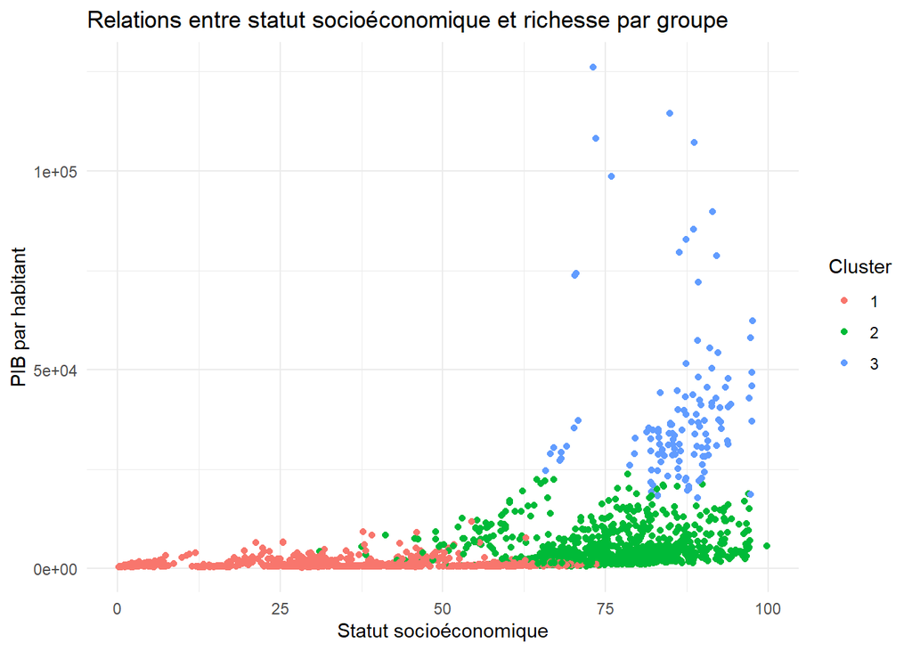

```r
# Graphique de dispersion pour SES vs. PIB par habitant
ggplot(completedData, aes(x = SES, y = gdppc, color = factor(cluster))) +
  geom_point() +
  labs(title = "Relations entre statut socioéconomique et richesse par groupe",
       x = "Statut socioéconomique",
       y = "PIB par habitant",
       color = "Cluster") +
  theme_minimal()
```

# Analyse du développement socioéconomique et de l’impact de l’éducation

Le statut socioéconomique SES et le niveau de développement économique d’une nation sont influencés par de multiples facteurs interdépendants. Cette analyse explore le rôle clé joué par l’éducation, ainsi que les liens complexes avec d’autres dimensions telles que les politiques économiques, la stabilité politique et la gouvernance. L’objectif est de dégager les dynamiques et les enseignements permettant d’orienter des stratégies de développement socioéconomique efficaces à long terme.

**Corrélations entre éducation, SES et PIB par habitant**

L’analyse des données révèle des tendances distinctes selon les niveaux d’éducation atteints :

```
Cluster 1
```

Ce cluster représente des régions avec un développement socioéconomique limité, manifesté par des niveaux bas d’éducation, de SES, et de PIB par habitant. La faible corrélation entre le SES et l’éducation ainsi que le SES et le PIB par habitant souligne un impact modeste de ces facteurs sur l’amélioration du bien-être. Néanmoins, une corrélation plus forte entre l’éducation et le PIB par habitant suggère un potentiel significatif pour l’éducation de stimuler la croissance économique, bien que cela nécessite des investissements substantiels pour transformer ce potentiel en progrès socioéconomique tangible.

```
Cluster 2
```

Les régions de ce cluster affichent des niveaux intermédiaires d’éducation et de SES, avec un PIB par habitant modéré, ce qui reflète un développement socioéconomique plus avancé par rapport au Cluster 1. La corrélation accrue entre l’éducation et le SES indique que l’éducation joue un rôle plus central dans la promotion du bien-être économique et social. Une croissance économique plus inclusive et équilibrée reste cependant nécessaire pour élever davantage le SES.

```
Cluster 3
```

Le troisième cluster inclut des régions avec un niveau élevé de développement, comme le démontrent les indices d’éducation, de SES, et de PIB par habitant. La forte corrélation entre le SES et l’éducation valide le rôle essentiel de l’éducation dans l’amélioration du bien-être. Toutefois, la légère corrélation négative avec le PIB par habitant indique que des revenus plus élevés ne garantissent pas automatiquement un meilleur bien-être socioéconomique, mettant en avant la nécessité d’adopter des politiques sociales pour assurer une distribution des richesses plus juste et équitable.

```r
# Exploration par ANOVA et tests post-hoc
anova_result <- aov(SES ~ country, data = completedData)
summary_anova <- summary(anova_result)

print("Résultats de l'ANOVA pour vérifier les différences de SES entre les pays :")
```

```
## [1] "Résultats de l'ANOVA pour vérifier les différences de SES entre les pays :"
```

```r
print(summary_anova)
```

```
##               Df  Sum Sq Mean Sq F value Pr(>F)
## country      148 1147199    7751     105 <2e-16 ***
## Residuals   1937  142997      74
## ---
## Signif. codes:  0 '***' 0.001 '**' 0.01 '*' 0.05 '.' 0.1 ' ' 1
```

```r
p_value <- summary_anova[[1]]$"Pr(>F)"[1]

if (p_value < 0.05) {
  tukey_result <- TukeyHSD(anova_result)
  print("Résultats du test post-hoc de Tukey :")
  print(tukey_result)
}
```

[output not shown]

[output cut: 22006 more lines]

[output not shown]

```r
# Analyse de Régression Multivariée
data_analysis <- na.omit(completedData[, c("yrseduc", "SES", "gdppc")])
model <- lm(gdppc ~ yrseduc + SES, data = data_analysis)

summary(model)
```

```
##
## Call:
## lm(formula = gdppc ~ yrseduc + SES, data = data_analysis)
##
## Residuals:
##    Min     1Q Median     3Q    Max
## -14558  -3774    551   2348  97525
##
## Coefficients:
##             Estimate Std. Error t value Pr(>|t|)
## (Intercept) -704.529    445.735  -1.581    0.114
## yrseduc     2566.907     76.223  33.676  < 2e-16 ***
## SES          -58.752      9.688  -6.065 1.57e-09 ***
## ---
## Signif. codes:  0 '***' 0.001 '**' 0.01 '*' 0.05 '.' 0.1 ' ' 1
##
## Residual standard error: 7946 on 2083 degrees of freedom
## Multiple R-squared:  0.4499, Adjusted R-squared:  0.4494
## F-statistic: 851.9 on 2 and 2083 DF,  p-value: < 2.2e-16
```

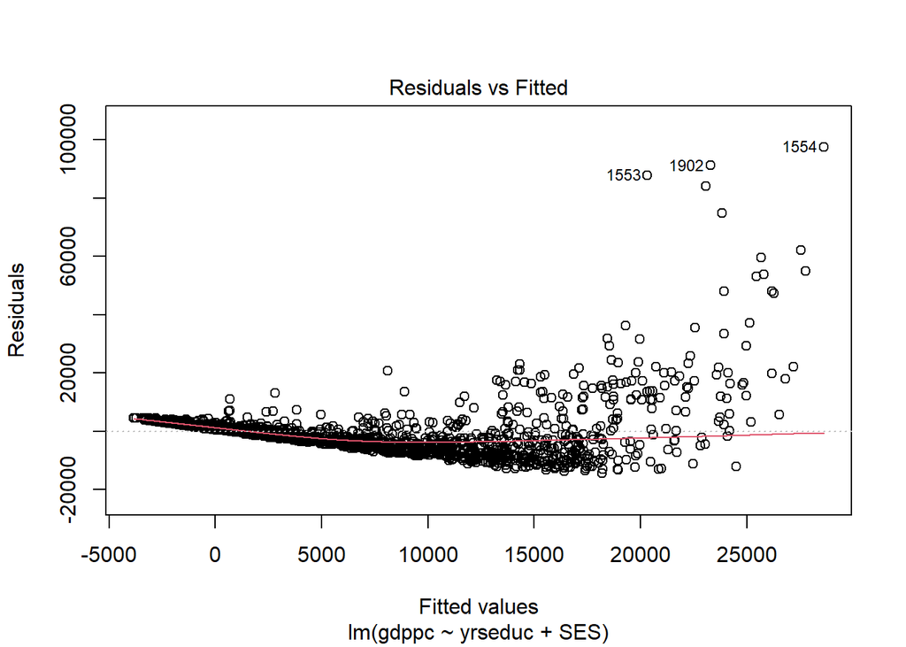

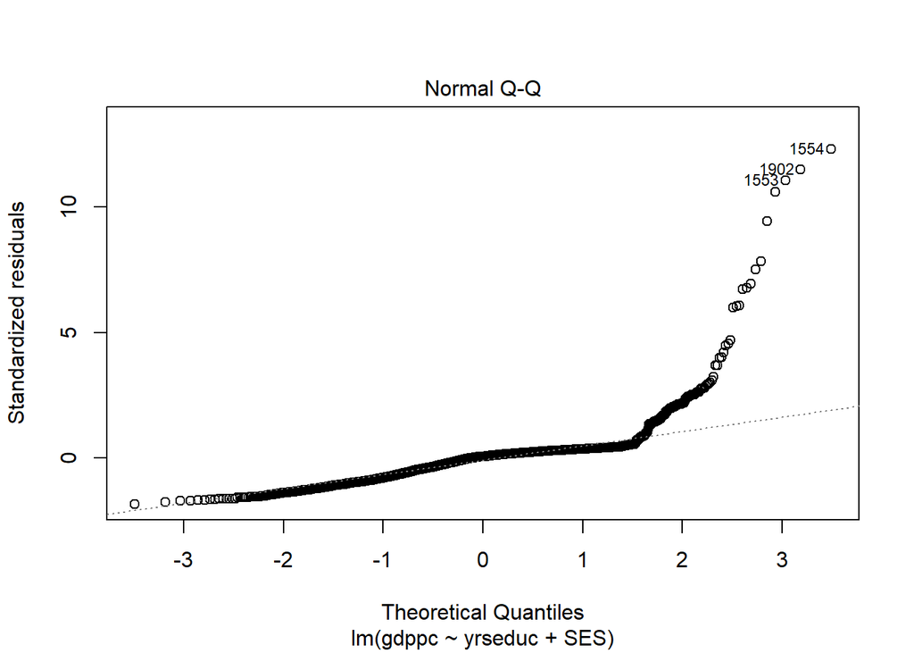

```r
# Vérification des diagnostics de régression
plot(model, which = 1:2)
```

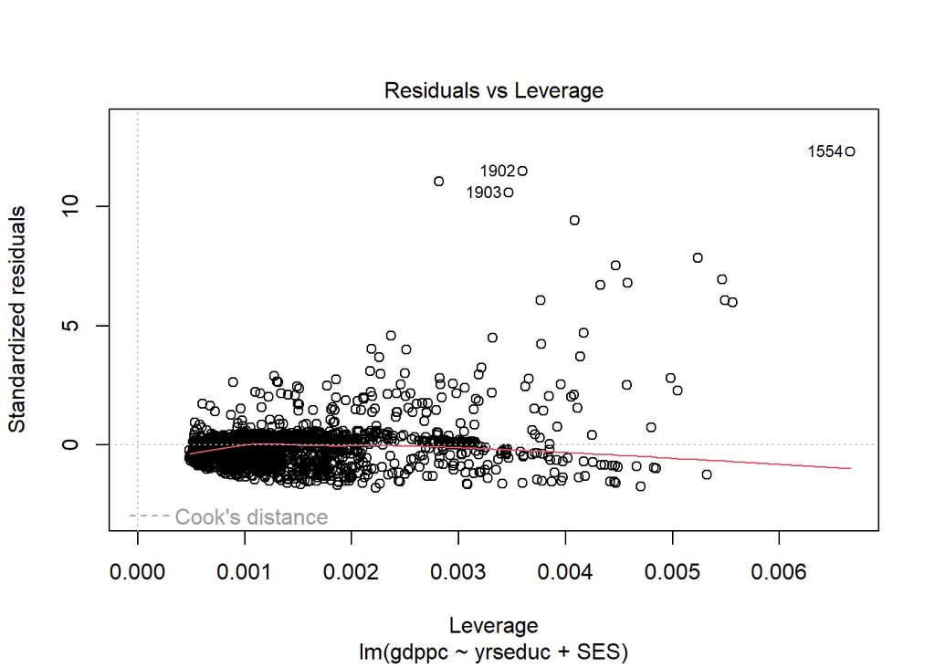

```r
plot(model, which = 5)
```

```r
vif(model)
```

```
##  yrseduc      SES
## 1.918018 1.918018
```

```r
robust_model <- coeftest(model, vcov = vcovHC(model, type = "HC1"))
print(robust_model)
```

```
##
## t test of coefficients:
##
##              Estimate Std. Error t value  Pr(>|t|)
## (Intercept) -704.5288   257.8512 -2.7323  0.006342 **
## yrseduc     2566.9070   161.7770 15.8669 < 2.2e-16 ***
## SES          -58.7517     9.9112 -5.9278 3.584e-09 ***
## ---
## Signif. codes:  0 '***' 0.001 '**' 0.01 '*' 0.05 '.' 0.1 ' ' 1
```

# Disparités et dynamiques socioéconomiques globales : Une exploration multidimensionnelle

La recherche approfondie sur les tendances socioéconomiques mondiales révèle une riche diversité, façonnée par les spécificités politiques, économiques et éducatives de chaque pays. Grâce à des méthodes statistiques avancées, notamment l’analyse de variance (ANOVA) et la régression multivariée, d’importantes disparités de statuts socioéconomiques (SES) ont été identifiées à travers les nations. L’ANOVA, en particulier, avec une valeur F de 105 et une probabilité extrêmement faible (inférieure à 2e-16), confirme que le SES diffère considérablement selon les pays, influencé par une gamme de facteurs allant des politiques gouvernementales à la conjoncture économique et à la configuration sociale.

Les tests post-hoc de Tukey ont révélé des contrastes précis entre les pays; par exemple, l’Albanie présente un SES nettement supérieur à celui de l’Afghanistan, avec une différence moyenne de 50.35 et un intervalle de confiance de 35.79 à 64.90. D’autres comparaisons révèlent des écarts significatifs, comme entre l’Argentine et l’Afghanistan, où l’Argentine montre un SES supérieur de 63.04 points, illustrant les différences marquées entre les pays en fonction de leur stade de développement.

Comme souligné précédemment, l’analyse révèle une corrélation positive significative entre l’éducation et le PIB par habitant avec un coefficient de 2566.907 (p < 2e-16), confirmant l’influence de l’éducation sur le développement économique. En parallèle, elle révèle une relation négative entre le statut socioéconomique (SES) et le PIB par habitant, avec un coefficient de -58.752 (p < 1.57e-09), indiquant que les hausses de revenu ne garantissent pas une amélioration correspondante du bien-être socioéconomique. Cette contradiction met en lumière les insuffisances du PIB par habitant comme mesure de prospérité, en particulier sa capacité à refléter les nuances du bien-être social et les disparités croissantes au sein des sociétés. Des recherches telles que celles de Piketty (2013) et Milanovic (2016) ont documenté l’aggravation des inégalités, même en période de croissance économique, avec une concentration de la richesse de plus en plus marquée chez les plus aisés. Cette situation interroge sur l’efficacité des systèmes fiscaux actuels et des politiques de redistribution dans leur rôle à contrer l’escalade des inégalités. Elle souligne la nécessité d’adopter une approche plus nuancée pour mesurer le développement, en intégrant des indicateurs tels que l’accès à l’éducation, la qualité des soins de santé, et la sécurité, éléments souvent omis par les mesures conventionnelles comme le PIB. Les travaux de Stiglitz et al. (2009) renforcent cette perspective, affirmant que les améliorations dans ces domaines sont indispensables pour un développement socioéconomique réellement durable et inclusif.

[output not shown]

En somme, l’étude révèle les nuances des dynamiques socioéconomiques, montrant que, malgré les contributions significatives de l’éducation au développement économique, le PIB par habitant reste insuffisant pour capturer pleinement le bien-être et les inégalités. Elle souligne la nécessité de politiques plus inclusives qui adoptent une approche multidimensionnelle du développement, suggérant des ajustements méthodologiques et des recherches futures pour explorer en profondeur les interactions entre SES, éducation et croissance économique. Ces informations appellent à une action ciblée, visant à atténuer les inégalités et à investir dans le capital humain, pour favoriser un développement socioéconomique durable et inclusif.

| **13. Étude de cas** |
| --- |

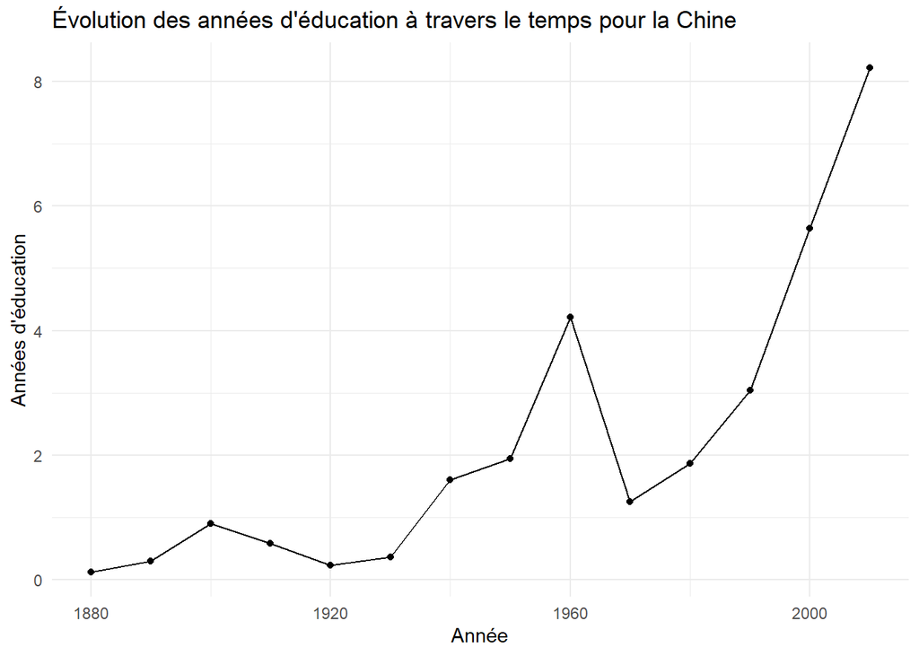

```r
# Filtrer les données pour la Chine uniquement
data_china <- completedData %>% filter(country == "China")

# Visualiser l'évolution des années d'éducation à travers le temps pour la Chine
ggplot(data_china, aes(x = year, y = yrseduc)) +
  geom_line() +
  geom_point() +
  labs(
    title = "Évolution des années d'éducation à travers le temps pour la Chine",
    x = "Année",
    y = "Années d'éducation"
  ) +
  theme_minimal()
```

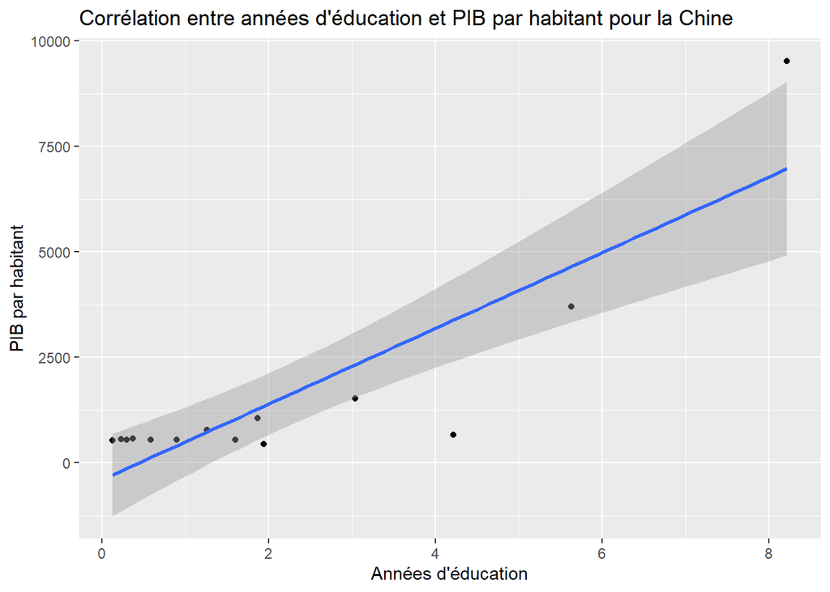

```r
# Corrélations entre variables pour la Chine
# Nuage de points entre années d'éducation et PIB par habitant
ggplot(data_china, aes(x = yrseduc, y = gdppc)) +
  geom_point() +
  geom_smooth(method = "lm") +
  labs(title = "Corrélation entre années d'éducation et PIB par habitant pour la Chine",
       x = "Années d'éducation",
       y = "PIB par habitant")
```